**Trabalho de Conclusão de Curso**  
**PONTIFÍCIA UNIVERSIDADE CATÓLICA DE MINAS GERAIS**  
**Curso:** *Pós-graduação Lato Sensu em Ciência de Dados e Big Data*  
**Aluno:** *Geraldo Rodrigues Novais Junior*

# Projeto:

# CIÊNCIA DE DADOS NO ESPORTE - Prevendo vencedores de jogos da NBA

## Objetivo:

A proposta é confirmar se é possível, além da aleatoriedade ou da probabilidade básica de cinquenta por cento para cada equipe, prever o resultado de um jogo da NBA com base em números e estatísticas coletadas durante uma temporada específica.

Iremos analisar dados de jogos da NBA desde a temporada de 2003, destacando uma temporada mais recente para realizar previsões. Será muito importante transformar essa base de previsões, afinal não poderemos usar os dados reais dessas partidas. Ao simular uma nova temporada, queremos prever os jogos que ainda não ocorreram e utilizar os próprios dados das partidas nas previsões seria como utilizar “dados futuros”. Durante o processo visualizaremos que utilizar “dados futuros” nos testes trariam falsas métricas de desempenho para os modelos, alcançando sem muito esforço acurácias superiores a oitenta por cento, o que certamente não representaria a realidade. Utilizaremos então como atributos de previsão as estatísticas acumuladas durante a temporada, apenas até os jogos que antecedem a partida a ser prevista.

Diante de toda complexidade já contextualizada, não há qualquer pretensão de se construir modelos com alta capacidade de precisão (afinal se isso fosse possível o torneio já teria perdido prestígio por ser altamente previsível), mas sim apontar o favoritismo de uma das equipes com base em dados, conceitos estatísticos e aprendizado de máquina. Em uma rápida pesquisa na internet, em sites de apostas ou mesmo de “palpites”, não é difícil perceber que as probabilidades de vitória de uma equipe em um jogo da NBA raramente alcançam um índice de sessenta por cento, sendo assim definiremos como meta que os modelos utilizados para as conclusões tenham ao menos um índice de precisão de sessenta por cento ou muito próximo disso.

## Coleta de Dados:

Os conjuntos que analisaremos foram retirados do site de competições [Kaggle](https://www.kaggle.com) em 23 de junho de 2020. Foram criados por Nathan Lauga e Ionas Kelepouris que mineraram os dados dos sites da [NBA](https://stats.nba.com) e [BasketBall Reference](https://www.basketball-reference.com), respectivamente.

## Descrição dos conjuntos:

### games.csv

link: [https://www.kaggle.com/nathanlauga/nba-games?select=games.csv]

- **GAME_DATE_EST** - Data do jogo;
- **GAME_ID** - ID do jogo;
- **GAME_STATUS_TEXT** - Status do jogo ("Final" significa que o foi concluído);
- **HOME_TEAM_ID** - ID da equipe anfitriã;
- **VISITOR_TEAM_ID** - ID da equipe visitante;
- **SEASON** - Temporada em que o jogo ocorreu;
- **TEAM_ID_home** - ID da equipe anfitriã (duplicado de "HOME_TEAM_ID");
- **PTS_home** - Número de pontos marcados pela equipe anfitriã;
- **FG_PCT_home** - Percentual de arremessos convertidos pela equipe anfitriã;
- **FT_PCT_home** - Percentual de Lances Livres convertidos pela equipe anfitriã;
- **FG3_PCT_home** - Percentual de arremessos de 3 pontos convertidos pela equipe anfitriã;
- **AST_home** - Número de assistências da equipe anfitriã;
- **REB_home** - Número de rebotes da equipe anfitriã;
- **TEAM_ID_away** - ID da equipe visitante (duplicado de "VISITOR_TEAM_ID");
- **PTS_away** - Número de pontos marcados pela equipe visitante;
- **FG_PCT_away** - Percentual de arremessos convertidos pela equipe visitante;
- **FT_PCT_away** - Percentual de Lances Livres convertidos pela equipe visitante;
- **FG3_PCT_away** - Percentual de arremessos de 3 pontos convertidos pela equipe visitante;
- **AST_away** - Número de assistências da equipe visitante;
- **REB_away** - Número de rebotes da equipe visitante;
- **HOME_TEAM_WINS** - Se a equipe anfitriã venceu o jogo (1 = Sim, 0 = Não).

### teams.csv

#### Conjunto com os dados das equipes. Se trata de um conjunto complementar ao contido no arquivo "games.csv" e são relacionados através de atributos com identificadores (ID) das equipes.

link: [https://www.kaggle.com/nathanlauga/nba-games?select=teams.csv]

- **LEAGUE_ID** - ID da liga (aqui, apenas NBA);
- **TEAM_ID** - ID da equipe;
- **MIN_YEAR** - Ano mínimo da equipe no campeonato da NBA;
- **MAX_YEAR** - Ano máximo da equipe no campeonato da NBA;
- **ABBREVIATION** - Abreviação do nome da equipe;
- **NICKNAME** - Apelido da equipe;
- **YEARFOUNDED** - Ano de Fundação;
- **CITY** - Cidade da equipe;
- **ARENA** - Arena da equipe;
- **ARENACAPACITY** - Capacidade da arena;
- **OWNER** - Dono da equipe (último);
- **GENERALMANAGER** - Gerente geral;
- **HEADCOACH** - Treinador;
- **DLEAGUEAFFILIATION** - Afiliação da Liga.

### nba.games.stats.csv

#### Conjunto com jogos da NBA da temporada 2014 a 2018. Neste novo conjunto temos atributos que não existem no primeiro arquivo "games.csv".

link: [https://www.kaggle.com/ionaskel/nba-games-stats-from-2014-to-2018?select=nba.games.stats.csv]

- **Team** - Nome da equipe;
- **Game** - Número do jogo (por equipe);
- **Date** - Data do jogo;
- **Home** - Se equipe anfitriã ou visitante;
- **Opponent** - Equipe oponente;
- **WINorLOSS** - Se vitória ou derrota;
- **TeamPoints** - Número de pontos da equipe;
- **OpponentPoints** - Número de pontos do oponente;
- **FieldGoals** - Arremessos convertidos pela equipe;
- **FieldGoalsAttempted** - Arremessos efetuados pela equipe;
- **FieldGoals.** - Percentual de arremessos convertidos pela equipe;
- **X3PointShots** - Arremessos de 3 pontos convertidos pela equipe;
- **X3PointShotsAttempted** - Arremessos de 3 pontos efetuados pela equipe;
- **X3PointShots.** - Percentual de arremessos de 3 pontos convertidos pela equipe;
- **FreeThrows** - Lances livres convertidos pela equipe;
- **FreeThrowsAttempted** - Lances livres efetuados pela equipe;
- **FreeThrows.** - Percentual de lances livres convertidos pela equipe;
- **OffRebounds** - Número de rebotes ofensivos da equipe;
- **TotalRebounds** - Número total de rebotes da equipe;
- **Assists** - Número de assistencias da equipe;
- **Steals** - Número de bolas roubadas pela equipe;
- **Blocks** - Número de bloqueios ("toco") efetuados pela equipe;
- **Turnovers** - Número de bolas perdidas pela equipe;
- **TotalFouls** - Número de faltas da equipe;
- **Opp.FieldGoals** - Arremessos convertidos pelo oponente;
- **Opp.FieldGoalsAttempted** - Arremessos efetuados pelo oponente;
- **Opp.FieldGoals.** - Percentual de arremessos convertidos pelo oponente;
- **Opp.3PointShots** - Arremessos de 3 pontos convertidos pelo oponente;
- **Opp.3PointShotsAttempted** - Arremessos de 3 pontos efetuados pelo oponente;
- **Opp.3PointShots.** - Percentual de arremessos de 3 pontos convertidos pelo oponente;
- **Opp.FreeThrows** - Lances livres convertidos pelo oponente;
- **Opp.FreeThrowsAttempted** - Lances livres efetuados pelo oponente;
- **Opp.FreeThrows.** - Percentual de lances livres convertidos pelo oponente;
- **Opp.OffRebounds** - Número de rebotes ofensivos do oponente;
- **Opp.TotalRebounds** - Número total de rebotes do oponente;
- **Opp.Assists** - Número de assistencias do oponente;
- **Opp.Steals** - Número de bolas roubadas pelo oponente;
- **Opp.Blocks** - Número de bloqueios ("toco") efetuados pelo oponente;
- **Opp.Turnovers** - Número de bolas perdidas pelo oponente;
- **Opp.TotalFouls** - Número de faltas do oponente.

```python
# Bibliotecas
import numpy as np
import pandas as pd
import matplotlib.pyplot as plt
import seaborn as sns
from scipy import stats
from imblearn.under_sampling import RandomUnderSampler
from sklearn.preprocessing import StandardScaler
from sklearn.model_selection import train_test_split, GridSearchCV
from sklearn.metrics import accuracy_score, confusion_matrix
from sklearn.linear_model import LogisticRegression
from sklearn.ensemble import RandomForestClassifier
from sklearn.svm import SVC
from xgboost import XGBClassifier
import warnings

# Configurações de visualização
%matplotlib inline
warnings.filterwarnings("ignore")
pd.set_option('display.max_columns', 50)
pd.set_option('display.max_rows', 100)
```

## Processamento/Tratamento dos Dados

```python
# Importando dataset's
games = pd.read_csv('games.csv')
teams = pd.read_csv('teams.csv')
nbags = pd.read_csv('nba.games.stats.csv')
```

```python
# Padronizando nomes das variáveis (letras minúsculas e retirando possíveis caracteres de espaços do início ou fim):
games.rename(columns= lambda x: x.lower().strip(), inplace=True)
teams.rename(columns= lambda x: x.lower().strip(), inplace=True)
nbags.rename(columns= lambda x: x.lower().strip(), inplace=True)
```

```python
# Confirmando conteúdo, volume e tipos de dados do conjunto "games" (Relatório: Figura 2)
games.info()
```

```
<class 'pandas.core.frame.DataFrame'>
RangeIndex: 23195 entries, 0 to 23194
Data columns (total 21 columns):
game_date_est       23195 non-null object
game_id             23195 non-null int64
game_status_text    23195 non-null object
home_team_id        23195 non-null int64
visitor_team_id     23195 non-null int64
season              23195 non-null int64
team_id_home        23195 non-null int64
pts_home            23096 non-null float64
fg_pct_home         23096 non-null float64
ft_pct_home         23096 non-null float64
fg3_pct_home        23096 non-null float64
ast_home            23096 non-null float64
reb_home            23096 non-null float64
team_id_away        23195 non-null int64
pts_away            23096 non-null float64
fg_pct_away         23096 non-null float64
ft_pct_away         23096 non-null float64
fg3_pct_away        23096 non-null float64
ast_away            23096 non-null float64
reb_away            23096 non-null float64
home_team_wins      23195 non-null int64
dtypes: float64(12), int64(7), object(2)
memory usage: 3.7+ MB
```

```python
# Visualizando os primeiros registros do dataframe games
games.head()
```

|  | game_date_est | game_id | game_status_text | home_team_id | visitor_team_id | season | team_id_home | pts_home | fg_pct_home | ft_pct_home | fg3_pct_home | ast_home | reb_home | team_id_away | pts_away | fg_pct_away | ft_pct_away | fg3_pct_away | ast_away | reb_away | home_team_wins |
| --- | --- | --- | --- | --- | --- | --- | --- | --- | --- | --- | --- | --- | --- | --- | --- | --- | --- | --- | --- | --- | --- |
| 0 | 2020-03-01 | 21900895 | Final | 1610612766 | 1610612749 | 2019 | 1610612766 | 85.0 | 0.354 | 0.900 | 0.229 | 22.0 | 47.0 | 1610612749 | 93.0 | 0.402 | 0.762 | 0.226 | 20.0 | 61.0 | 0 |
| 1 | 2020-03-01 | 21900896 | Final | 1610612750 | 1610612742 | 2019 | 1610612750 | 91.0 | 0.364 | 0.400 | 0.310 | 19.0 | 57.0 | 1610612742 | 111.0 | 0.468 | 0.632 | 0.275 | 28.0 | 56.0 | 0 |
| 2 | 2020-03-01 | 21900897 | Final | 1610612746 | 1610612755 | 2019 | 1610612746 | 136.0 | 0.592 | 0.805 | 0.542 | 25.0 | 37.0 | 1610612755 | 130.0 | 0.505 | 0.650 | 0.488 | 27.0 | 37.0 | 1 |
| 3 | 2020-03-01 | 21900898 | Final | 1610612743 | 1610612761 | 2019 | 1610612743 | 133.0 | 0.566 | 0.700 | 0.500 | 38.0 | 41.0 | 1610612761 | 118.0 | 0.461 | 0.897 | 0.263 | 24.0 | 36.0 | 1 |
| 4 | 2020-03-01 | 21900899 | Final | 1610612758 | 1610612765 | 2019 | 1610612758 | 106.0 | 0.407 | 0.885 | 0.257 | 18.0 | 51.0 | 1610612765 | 100.0 | 0.413 | 0.667 | 0.429 | 23.0 | 42.0 | 1 |

```python
# Confirmando conteúdo, volume e tipos de dados do conjunto "teams" (Relatório: Figura 3)
teams.info()
```

```
<class 'pandas.core.frame.DataFrame'>
RangeIndex: 30 entries, 0 to 29
Data columns (total 14 columns):
league_id             30 non-null int64
team_id               30 non-null int64
min_year              30 non-null int64
max_year              30 non-null int64
abbreviation          30 non-null object
nickname              30 non-null object
yearfounded           30 non-null int64
city                  30 non-null object
arena                 30 non-null object
arenacapacity         26 non-null float64
owner                 30 non-null object
generalmanager        30 non-null object
headcoach             30 non-null object
dleagueaffiliation    30 non-null object
dtypes: float64(1), int64(5), object(8)
memory usage: 3.4+ KB
```

```python
# Visualizando os primeiros registros do dataframe teams
teams.head()
```

|  | league_id | team_id | min_year | max_year | abbreviation | nickname | yearfounded | city | arena | arenacapacity | owner | generalmanager | headcoach | dleagueaffiliation |
| --- | --- | --- | --- | --- | --- | --- | --- | --- | --- | --- | --- | --- | --- | --- |
| 0 | 0 | 1610612737 | 1949 | 2019 | ATL | Hawks | 1949 | Atlanta | State Farm Arena | 18729.0 | Tony Ressler | Travis Schlenk | Lloyd Pierce | Erie Bayhawks |
| 1 | 0 | 1610612738 | 1946 | 2019 | BOS | Celtics | 1946 | Boston | TD Garden | 18624.0 | Wyc Grousbeck | Danny Ainge | Brad Stevens | Maine Red Claws |
| 2 | 0 | 1610612740 | 2002 | 2019 | NOP | Pelicans | 2002 | New Orleans | Smoothie King Center | NaN | Tom Benson | Trajan Langdon | Alvin Gentry | No Affiliate |
| 3 | 0 | 1610612741 | 1966 | 2019 | CHI | Bulls | 1966 | Chicago | United Center | 21711.0 | Jerry Reinsdorf | Gar Forman | Jim Boylen | Windy City Bulls |
| 4 | 0 | 1610612742 | 1980 | 2019 | DAL | Mavericks | 1980 | Dallas | American Airlines Center | 19200.0 | Mark Cuban | Donnie Nelson | Rick Carlisle | Texas Legends |

Já o conjunto importado do arquivo "teams.csv" possui 30 registros em um total de 14 atributos, contendo os dados nominais de cada equipe. Nos ajudará a enriquecer o conjunto "games.csv" com as siglas ou nomes das equipes, permitindo uma melhor identificação e construção de versões similares entre as bases que servirão de treinamento de modelos e de previsões. Existem dados faltantes em apenas um dos atributos, “arenacapacity”, o qual provavelmente não será utilizado no decorrer do processo.

```python
# Confirmando conteúdo, volume e tipos de dados do conjunto "nbags" (Relatório: Figura 4)
nbags.info()
```

```
<class 'pandas.core.frame.DataFrame'>
RangeIndex: 9840 entries, 0 to 9839
Data columns (total 41 columns):
unnamed: 0                  9840 non-null int64
team                        9840 non-null object
game                        9840 non-null int64
date                        9840 non-null object
home                        9840 non-null object
opponent                    9840 non-null object
winorloss                   9840 non-null object
teampoints                  9840 non-null int64
opponentpoints              9840 non-null int64
fieldgoals                  9840 non-null int64
fieldgoalsattempted         9840 non-null int64
fieldgoals.                 9840 non-null float64
x3pointshots                9840 non-null int64
x3pointshotsattempted       9840 non-null int64
x3pointshots.               9840 non-null float64
freethrows                  9840 non-null int64
freethrowsattempted         9840 non-null int64
freethrows.                 9840 non-null float64
offrebounds                 9840 non-null int64
totalrebounds               9840 non-null int64
assists                     9840 non-null int64
steals                      9840 non-null int64
blocks                      9840 non-null int64
turnovers                   9840 non-null int64
totalfouls                  9840 non-null int64
opp.fieldgoals              9840 non-null int64
opp.fieldgoalsattempted     9840 non-null int64
opp.fieldgoals.             9840 non-null float64
opp.3pointshots             9840 non-null int64
opp.3pointshotsattempted    9840 non-null int64
opp.3pointshots.            9840 non-null float64
opp.freethrows              9840 non-null int64
opp.freethrowsattempted     9840 non-null int64
opp.freethrows.             9840 non-null float64
opp.offrebounds             9840 non-null int64
opp.totalrebounds           9840 non-null int64
opp.assists                 9840 non-null int64
opp.steals                  9840 non-null int64
opp.blocks                  9840 non-null int64
opp.turnovers               9840 non-null int64
opp.totalfouls              9840 non-null int64
dtypes: float64(6), int64(30), object(5)
memory usage: 3.1+ MB
```

```python
# Visualizando os primeiros registros do dataframe nbags
nbags.head()
```

|  | unnamed: 0 | team | game | date | home | opponent | winorloss | teampoints | opponentpoints | fieldgoals | fieldgoalsattempted | fieldgoals. | x3pointshots | x3pointshotsattempted | x3pointshots. | freethrows | freethrowsattempted | freethrows. | offrebounds | totalrebounds | assists | steals | blocks | turnovers | totalfouls | opp.fieldgoals | opp.fieldgoalsattempted | opp.fieldgoals. | opp.3pointshots | … |
| --- | --- | --- | --- | --- | --- | --- | --- | --- | --- | --- | --- | --- | --- | --- | --- | --- | --- | --- | --- | --- | --- | --- | --- | --- | --- | --- | --- | --- | --- | --- |
| 0 | 1 | ATL | 1 | 2014-10-29 | Away | TOR | L | 102 | 109 | 40 | 80 | 0.500 | 13 | 22 | 0.591 | 9 | 17 | 0.529 | 10 | 42 | 26 | 6 | 8 | 17 | 24 | 37 | 90 | 0.411 | 8 | … |
| 1 | 2 | ATL | 2 | 2014-11-01 | Home | IND | W | 102 | 92 | 35 | 69 | 0.507 | 7 | 20 | 0.350 | 25 | 33 | 0.758 | 3 | 37 | 26 | 10 | 6 | 12 | 20 | 31 | 81 | 0.383 | 12 | … |
| 2 | 3 | ATL | 3 | 2014-11-05 | Away | SAS | L | 92 | 94 | 38 | 92 | 0.413 | 8 | 25 | 0.320 | 8 | 11 | 0.727 | 10 | 37 | 26 | 14 | 5 | 13 | 25 | 31 | 69 | 0.449 | 5 | … |
| 3 | 4 | ATL | 4 | 2014-11-07 | Away | CHO | L | 119 | 122 | 43 | 93 | 0.462 | 13 | 33 | 0.394 | 20 | 26 | 0.769 | 7 | 38 | 28 | 8 | 3 | 19 | 33 | 48 | 97 | 0.495 | 6 | … |
| 4 | 5 | ATL | 5 | 2014-11-08 | Home | NYK | W | 103 | 96 | 33 | 81 | 0.407 | 9 | 22 | 0.409 | 28 | 36 | 0.778 | 12 | 41 | 18 | 10 | 5 | 8 | 17 | 40 | 84 | 0.476 | 8 | … |

Por fim o conjunto importado do arquivo “nba.games.stats.csv”. Possui dados análogos aos do Data Frame "games", porém mais conteúdo, detalhes e sem dados faltantes. Temos por exemplo o número real de diversos atributos que permitirão transformá-lo em um novo conjunto onde os índices de desempenho das equipes sejam sumarizados e recalculados a cada nova rodada. Apesar de mais completo que os anteriores em seus 41 atributos, são poucas temporadas disponíveis nos seus 9.840 registros, podendo assim limitar o treinamento dos modelos. Ainda assim será de grande utilidade para destacar uma temporada específica, simular índices das equipes antes de cada partida e termos uma base de previsões para testarmos o desempenho dos modelos em predições de jogos futuros.

**Tratamento e criação da Base Histórica**:

Primeiramente, enriquecemos o conjunto "games" com a identificação das equipes anfitriã e visitante. Para isso, faremos dois subconjuntos do Data Frame “teams” onde temos apenas as variáveis “team_id” e “abbreviation”. No primeiro subconjunto o atributo “team_id” é renomeado para “home_team_id”, enquanto no segundo para “away_team_id”. Estas variáveis servirão de referência para a junção com o Data Frame “games”. Já o atributo “abbreviation” é renomeado para “home” e “away” respectivamente, agregando assim a identificação das equipes por meio das abreviaturas de seus nomes.

```python
# Destacando do dataset teams os IDs e os nomes das equipes (abreviados) e renomeando as variáveis.
dfTeamHome = teams[['team_id', 'abbreviation']].rename(columns={"team_id": "home_team_id", "abbreviation": "home"})
dfTeamAway = teams[['team_id', 'abbreviation']].rename(columns={"team_id": "visitor_team_id", "abbreviation": "away"})
```

```python
# Visualizando os primeiros registros do dataframe dfTeamHome (Relatório: Figura 5)
dfTeamHome.head()
```

|  | home_team_id | home |
| --- | --- | --- |
| 0 | 1610612737 | ATL |
| 1 | 1610612738 | BOS |
| 2 | 1610612740 | NOP |
| 3 | 1610612741 | CHI |
| 4 | 1610612742 | DAL |

```python
# Visualizando os primeiros registros do dataframe dfTeamAway (Relatório: Figura 5)
dfTeamAway.head()
```

|  | visitor_team_id | away |
| --- | --- | --- |
| 0 | 1610612737 | ATL |
| 1 | 1610612738 | BOS |
| 2 | 1610612740 | NOP |
| 3 | 1610612741 | CHI |
| 4 | 1610612742 | DAL |

```python
# Unificando ao dataframe games as siglas das equipes
games = pd.merge(games, dfTeamHome, how='left', on=['home_team_id'])
games = pd.merge(games, dfTeamAway, how='left', on=['visitor_team_id'])
```

```python
# Visualizando os primeiros registros do dataframe unificado
games.head()
```

|  | game_date_est | game_id | game_status_text | home_team_id | visitor_team_id | season | team_id_home | pts_home | fg_pct_home | ft_pct_home | fg3_pct_home | ast_home | reb_home | team_id_away | pts_away | fg_pct_away | ft_pct_away | fg3_pct_away | ast_away | reb_away | home_team_wins | home | away |
| --- | --- | --- | --- | --- | --- | --- | --- | --- | --- | --- | --- | --- | --- | --- | --- | --- | --- | --- | --- | --- | --- | --- | --- |
| 0 | 2020-03-01 | 21900895 | Final | 1610612766 | 1610612749 | 2019 | 1610612766 | 85.0 | 0.354 | 0.900 | 0.229 | 22.0 | 47.0 | 1610612749 | 93.0 | 0.402 | 0.762 | 0.226 | 20.0 | 61.0 | 0 | CHA | MIL |
| 1 | 2020-03-01 | 21900896 | Final | 1610612750 | 1610612742 | 2019 | 1610612750 | 91.0 | 0.364 | 0.400 | 0.310 | 19.0 | 57.0 | 1610612742 | 111.0 | 0.468 | 0.632 | 0.275 | 28.0 | 56.0 | 0 | MIN | DAL |
| 2 | 2020-03-01 | 21900897 | Final | 1610612746 | 1610612755 | 2019 | 1610612746 | 136.0 | 0.592 | 0.805 | 0.542 | 25.0 | 37.0 | 1610612755 | 130.0 | 0.505 | 0.650 | 0.488 | 27.0 | 37.0 | 1 | LAC | PHI |
| 3 | 2020-03-01 | 21900898 | Final | 1610612743 | 1610612761 | 2019 | 1610612743 | 133.0 | 0.566 | 0.700 | 0.500 | 38.0 | 41.0 | 1610612761 | 118.0 | 0.461 | 0.897 | 0.263 | 24.0 | 36.0 | 1 | DEN | TOR |
| 4 | 2020-03-01 | 21900899 | Final | 1610612758 | 1610612765 | 2019 | 1610612758 | 106.0 | 0.407 | 0.885 | 0.257 | 18.0 | 51.0 | 1610612765 | 100.0 | 0.413 | 0.667 | 0.429 | 23.0 | 42.0 | 1 | SAC | DET |

```python
# listando nomes de todas colunas do dataframe games
games.columns
```

```
Index(['game_date_est', 'game_id', 'game_status_text', 'home_team_id',
       'visitor_team_id', 'season', 'team_id_home', 'pts_home', 'fg_pct_home',
       'ft_pct_home', 'fg3_pct_home', 'ast_home', 'reb_home', 'team_id_away',
       'pts_away', 'fg_pct_away', 'ft_pct_away', 'fg3_pct_away', 'ast_away',
       'reb_away', 'home_team_wins', 'home', 'away'],
      dtype='object')
```

```python
# Selecionando as variáveis pra continuidade do projeto e renomeando o dataframe pra dfGames
dfGames = games[['season', 'home', 'away',
                 'fg_pct_home', 'ft_pct_home', 'fg3_pct_home', 'ast_home', 'reb_home',
                 'fg_pct_away', 'ft_pct_away', 'fg3_pct_away', 'ast_away', 'reb_away',
                 'home_team_wins']]
```

```python
# Visualizando os primeiros registros do dataframe dfGames (Relatório: Figura 6)
dfGames.head()
```

|  | season | home | away | fg_pct_home | ft_pct_home | fg3_pct_home | ast_home | reb_home | fg_pct_away | ft_pct_away | fg3_pct_away | ast_away | reb_away | home_team_wins |
| --- | --- | --- | --- | --- | --- | --- | --- | --- | --- | --- | --- | --- | --- | --- |
| 0 | 2019 | CHA | MIL | 0.354 | 0.900 | 0.229 | 22.0 | 47.0 | 0.402 | 0.762 | 0.226 | 20.0 | 61.0 | 0 |
| 1 | 2019 | MIN | DAL | 0.364 | 0.400 | 0.310 | 19.0 | 57.0 | 0.468 | 0.632 | 0.275 | 28.0 | 56.0 | 0 |
| 2 | 2019 | LAC | PHI | 0.592 | 0.805 | 0.542 | 25.0 | 37.0 | 0.505 | 0.650 | 0.488 | 27.0 | 37.0 | 1 |
| 3 | 2019 | DEN | TOR | 0.566 | 0.700 | 0.500 | 38.0 | 41.0 | 0.461 | 0.897 | 0.263 | 24.0 | 36.0 | 1 |
| 4 | 2019 | SAC | DET | 0.407 | 0.885 | 0.257 | 18.0 | 51.0 | 0.413 | 0.667 | 0.429 | 23.0 | 42.0 | 1 |

```python
# Conferindo colunas com dados faltantes (missing) - (Relatório: Figura 7)
print('Quantidade de registros(linhas) do dataset: ', dfGames.shape[0])
print('Quantidade de registros(linhas) com dados faltantes:')
dfGames.isnull().sum()
```

```
Quantidade de registros(linhas) do dataset:  23195
Quantidade de registros(linhas) com dados faltantes:
```

```
season             0
home               0
away               0
fg_pct_home       99
ft_pct_home       99
fg3_pct_home      99
ast_home          99
reb_home          99
fg_pct_away       99
ft_pct_away       99
fg3_pct_away      99
ast_away          99
reb_away          99
home_team_wins     0
dtype: int64
```

Observamos dados faltantes em 99 registros de uma grande parte dos atributos, justamente aqueles com potencial para serem nossas variáveis preditoras. Apesar da importância dos atributos, a quantidade de registros nesta condição representa menos de 0,5% do total, sendo assim a remoção pouco impactaria o volume de treinamento para os modelos. Dado o exposto, optamos por excluir os registros com dados faltantes.

```python
# Excluindo registros com dados missing do dataframe dfGames:
dfGames = dfGames.dropna()
```

```python
# Conferindo resultado da limpeza de dados faltantes (missing) - (Relatório: Figura 8)
print('Quantidade de registros(linhas) do dataset: ', dfGames.shape[0])
print('Quantidade de registros(linhas) com dados faltantes:')
dfGames.isnull().sum()
```

```
Quantidade de registros(linhas) do dataset:  23096
Quantidade de registros(linhas) com dados faltantes:
```

```
season            0
home              0
away              0
fg_pct_home       0
ft_pct_home       0
fg3_pct_home      0
ast_home          0
reb_home          0
fg_pct_away       0
ft_pct_away       0
fg3_pct_away      0
ast_away          0
reb_away          0
home_team_wins    0
dtype: int64
```

```python
# Conferindo se há registros duplicados para serem tratados (Relatório: Figura 9)
print('Quantidade de registros(linhas) do dataset: ', dfGames.shape[0])
print('Quantidade de registros(linhas) duplicados a serem tratados: ', sum(dfGames.duplicated()))
```

```
Quantidade de registros(linhas) do dataset:  23096
Quantidade de registros(linhas) duplicados a serem tratados:  0
```

Após os tratamentos iniciais, não observamos registros duplicados.  
Vamos agora tratar o dataset "nbags" que será utilizado para teste dos modelos em uma nova temporada. Voltaremos ao conjunto "dfGames" ao longo deste tratamento quando iremos selecionar quais temporadas farão parte dos dados históricos para treinamento e validação.

**Tratamento e criação da Base de Previsões**:

Em nosso trabalho a Base Histórica não poderá ser dividia em parte de treino e parte de teste como tradicionalmente ocorre em muitos outros projetos. Isso porque como já mencionado em capítulos anteriores, queremos prever os jogos que ainda não ocorreram e utilizar os próprios dados das partidas nas previsões seria como utilizar “dados futuros”.

Diante do exposto, recorreremos ao conjunto “nbags” que, como já vimos nas avaliações iniciais, possui os atributos necessários para criarmos a Base de Previsões, que servirá como teste para os modelos.

O objetivo é simular a situação que teríamos se estivéssemos vivenciando uma nova temporada da NBA, ou seja, não temos os dados da partida que ainda vai ocorrer. E como faremos isso? A cada rodada, vamos sumarizar os números que as equipes obtiveram durante as partidas já ocorridas e obter os índices acumulados delas até aquele momento. Estes índices acumulados servirão de variáveis para previsão dos resultados da próxima rodada.

Parte importante do conhecimento do negócio, sabemos que o desempenho de equipes esportivas tende a ser diferente de quando jogam fora de sua arena, então montaremos esses índices separados de quando as equipes atuam como anfitriãs ou visitantes. Sabemos ainda que as equipes se modificam muito de uma temporada para outra, por isso destacaremos uma única temporada para teste e não utilizaremos números de partidas que ocorreram em uma anterior. Obviamente não teremos previsões para as primeiras rodadas da temporada em simulação por não existir ainda índices para inserir nos modelos.

Precisamos então tratar e transformar os dados do conjunto “nbags”, criando a Base de Previsões (ou Base de Testes) segundo os conceitos citados acima e respeitando o mesmo layout da Base Histórica. Mas antes, temos que definir qual temporada será utilizada nas previsões.

```python
# Visualizando mais uma vez os primeiros registros do dataframe nbags
nbags.head()
```

|  | unnamed: 0 | team | game | date | home | opponent | winorloss | teampoints | opponentpoints | fieldgoals | fieldgoalsattempted | fieldgoals. | x3pointshots | x3pointshotsattempted | x3pointshots. | freethrows | freethrowsattempted | freethrows. | offrebounds | totalrebounds | assists | steals | blocks | turnovers | totalfouls | opp.fieldgoals | opp.fieldgoalsattempted | opp.fieldgoals. | opp.3pointshots | … |
| --- | --- | --- | --- | --- | --- | --- | --- | --- | --- | --- | --- | --- | --- | --- | --- | --- | --- | --- | --- | --- | --- | --- | --- | --- | --- | --- | --- | --- | --- | --- |
| 0 | 1 | ATL | 1 | 2014-10-29 | Away | TOR | L | 102 | 109 | 40 | 80 | 0.500 | 13 | 22 | 0.591 | 9 | 17 | 0.529 | 10 | 42 | 26 | 6 | 8 | 17 | 24 | 37 | 90 | 0.411 | 8 | … |
| 1 | 2 | ATL | 2 | 2014-11-01 | Home | IND | W | 102 | 92 | 35 | 69 | 0.507 | 7 | 20 | 0.350 | 25 | 33 | 0.758 | 3 | 37 | 26 | 10 | 6 | 12 | 20 | 31 | 81 | 0.383 | 12 | … |
| 2 | 3 | ATL | 3 | 2014-11-05 | Away | SAS | L | 92 | 94 | 38 | 92 | 0.413 | 8 | 25 | 0.320 | 8 | 11 | 0.727 | 10 | 37 | 26 | 14 | 5 | 13 | 25 | 31 | 69 | 0.449 | 5 | … |
| 3 | 4 | ATL | 4 | 2014-11-07 | Away | CHO | L | 119 | 122 | 43 | 93 | 0.462 | 13 | 33 | 0.394 | 20 | 26 | 0.769 | 7 | 38 | 28 | 8 | 3 | 19 | 33 | 48 | 97 | 0.495 | 6 | … |
| 4 | 5 | ATL | 5 | 2014-11-08 | Home | NYK | W | 103 | 96 | 33 | 81 | 0.407 | 9 | 22 | 0.409 | 28 | 36 | 0.778 | 12 | 41 | 18 | 10 | 5 | 8 | 17 | 40 | 84 | 0.476 | 8 | … |

```python
# Utilizando a coluna "date" para identificar as datas de jogos (e assim temporadas) estão disponíveis (Relatório: Figura 10)
sorted(nbags.date.str[:4].unique())
```

```
['2014', '2015', '2016', '2017', '2018']
```

Sabendo que as temporadas da NBA iniciam a partir de setembro e se encerram até junho do ano seguinte, temos a indicação que a temporada completa mais recente no conjunto "nbags" seria a de 2017. Para conferir comparamos ao conjunto "games", que possui todas as datas dos jogos até 2020, confirmando que a temporada mais recente e completa no conjunto "nbags" é de fato a citada inicialmente

```python
# Verificando data do(s) último(s) jogo(s) da temporada 2017 no dataframe games:
end2017 = games['game_date_est'][(games.season == 2017)].max()
print('Fim da Temporada 2017: {}'.format(end2017))
```

```
Fim da Temporada 2017: 2018-06-08
```

```python
# Verificando data do(s) último(s) jogo(s) de 2018 no dataframe nbags:
nbags[(nbags.date >= "2018-01-01")].date.max()
```

```
'2018-04-11'
```

Sendo a data máxima 11/04/2018, identificamos que de fato a última temporada no dataframe "nbags" é 2017.  
Nota-se que no dataframe "games" temos mais datas, sendo assim mais jogos. Isso ocorre porque no neste dataframe temos as datas de jogos dos "playoffs" enquanto no dataset "nbags" ao que tudo indica possui somente os jogos da temporada regular. Isso não interfere no nosso objetivo de testar o modelo em jogos futuros, mesmo assim podemos ratificar ao contar quantos jogos cada equipe fez em sua arena (a quantidade deve ser igual para todos se estivermos falando somente da temporada regular).

```python
nbags[(nbags.date >= "2017-07-01")].groupby("team")["team"].count()
```

```
team
ATL    82
BOS    82
BRK    82
CHI    82
CHO    82
CLE    82
DAL    82
DEN    82
DET    82
GSW    82
HOU    82
IND    82
LAC    82
LAL    82
MEM    82
MIA    82
MIL    82
MIN    82
NOP    82
NYK    82
OKC    82
ORL    82
PHI    82
PHO    82
POR    82
SAC    82
SAS    82
TOR    82
UTA    82
WAS    82
Name: team, dtype: int64
```

Confirmação feita, vamos destacar a temporada 2017 do dataframe "nbags", identificando a data mínima e máxima ainda com o auxílio do dataframe "games"

```python
# Verificando data do(s) primeiro(s) e último(s) jogo(s) da temporada 201 no dataframe games:
start2017 = games['game_date_est'][(games.season == 2017)].min()
end2017 = games['game_date_est'][(games.season == 2017)].max()

print('Inicio da Temporada 2017: {}'.format(start2017))
print('Fim da Temporada 2017: {}'.format(end2017))
```

```
Inicio da Temporada 2017: 2017-09-30
Fim da Temporada 2017: 2018-06-08
```

```python
# Destacando temporada 2017 do dataframe nbags, criando o dataframe stats2017, conferindo datas e volume
stats2017 = nbags[(nbags.date >= start2017) & (nbags.date <= end2017)]
print(stats2017.date.min())
print(stats2017.date.max())
stats2017.groupby('home')['game'].count()
```

```
2017-10-17
2018-04-11
```

```
home
Away    1230
Home    1230
Name: game, dtype: int64
```

```python
# Criando a coluna season
stats2017["season"] = "2017"
```

Filtrado o conjunto que agora contém apenas a temporada 2017, é importante destacar como os registros se comportam diferente entre as bases. Na Base histórica, uma única partida é um único registro contendo os atributos de equipes anfitriãs e visitantes. Já na Base de Testes um único jogo é registrado duas vezes, apenas alternando as equipes anfitriã e visitante. Podemos entender melhor o comportamento visualizando os registros de uma mesma partida nos dois conjuntos.

```python
# Confirmando registro único de partida em games (Relatório: Figura 11)
games[(games.game_date_est == "2017-10-18") & (games.home.isin(["ATL","DAL"]))] \
.loc[:,["home", "game_date_est", "away", "home_team_wins", "pts_home", "pts_away"]]
```

|  | home | game_date_est | away | home_team_wins | pts_home | pts_away |
| --- | --- | --- | --- | --- | --- | --- |
| 18879 | DAL | 2017-10-18 | ATL | 0 | 111.0 | 117.0 |

```python
# Confirmando duplicidade de partidas em stats2017 (Relatório: Figura 12)
stats2017[(stats2017.date == "2017-10-18") & (stats2017.team.isin(["ATL","DAL"]))].iloc[:,1:9]
```

|  | team | game | date | home | opponent | winorloss | teampoints | opponentpoints |
| --- | --- | --- | --- | --- | --- | --- | --- | --- |
| 7380 | ATL | 1 | 2017-10-18 | Away | DAL | W | 117 | 111 |
| 7872 | DAL | 1 | 2017-10-18 | Home | ATL | L | 111 | 117 |

```python
# Conferindo se há registros duplicados para serem tratados (Relatório: Figura 13)
print('Quantidade de registros(linhas) do dataset: ', stats2017.shape[0])
print('Quantidade de registros(linhas) duplicados a serem tratados: ', sum(stats2017.duplicated()))
```

```
Quantidade de registros(linhas) do dataset:  2460
Quantidade de registros(linhas) duplicados a serem tratados:  0
```

A diferença nos registros não impede a continuidade, mas precisaremos tratar corretamente a Base de Previsões para não duplicar jogos da temporada. Antes de continuarmos com os tratamentos, aproveitamos para confirmar que, mesmo com a condição visualizada acima, não há registros duplicados.

```python
# Conferindo se existem dados faltantes (missing) - (Relatório: Figura 14)
print('Quantidade de registros(linhas) do dataset: ', stats2017.shape[0])
print('Quantidade de registros(linhas) com dados faltantes:')
stats2017.isnull().sum()
```

```
Quantidade de registros(linhas) do dataset:  2460
Quantidade de registros(linhas) com dados faltantes:
```

```
unnamed: 0                  0
team                        0
game                        0
date                        0
home                        0
opponent                    0
winorloss                   0
teampoints                  0
opponentpoints              0
fieldgoals                  0
fieldgoalsattempted         0
fieldgoals.                 0
x3pointshots                0
x3pointshotsattempted       0
x3pointshots.               0
freethrows                  0
freethrowsattempted         0
freethrows.                 0
offrebounds                 0
totalrebounds               0
assists                     0
steals                      0
blocks                      0
turnovers                   0
totalfouls                  0
opp.fieldgoals              0
opp.fieldgoalsattempted     0
opp.fieldgoals.             0
opp.3pointshots             0
opp.3pointshotsattempted    0
opp.3pointshots.            0
opp.freethrows              0
opp.freethrowsattempted     0
opp.freethrows.             0
opp.offrebounds             0
opp.totalrebounds           0
opp.assists                 0
opp.steals                  0
opp.blocks                  0
opp.turnovers               0
opp.totalfouls              0
season                      0
dtype: int64
```

Confirmamos ainda que não existem dados faltantes no conjunto em tratamento. Seguimos para a seleção das variáveis, separação, transformação e por fim recombinar os conjuntos.

```python
# Visualizando os nomes das variáveis do dataframe stats2017
stats2017.columns
```

```
Index(['unnamed: 0', 'team', 'game', 'date', 'home', 'opponent', 'winorloss',
       'teampoints', 'opponentpoints', 'fieldgoals', 'fieldgoalsattempted',
       'fieldgoals.', 'x3pointshots', 'x3pointshotsattempted', 'x3pointshots.',
       'freethrows', 'freethrowsattempted', 'freethrows.', 'offrebounds',
       'totalrebounds', 'assists', 'steals', 'blocks', 'turnovers',
       'totalfouls', 'opp.fieldgoals', 'opp.fieldgoalsattempted',
       'opp.fieldgoals.', 'opp.3pointshots', 'opp.3pointshotsattempted',
       'opp.3pointshots.', 'opp.freethrows', 'opp.freethrowsattempted',
       'opp.freethrows.', 'opp.offrebounds', 'opp.totalrebounds',
       'opp.assists', 'opp.steals', 'opp.blocks', 'opp.turnovers',
       'opp.totalfouls', 'season'],
      dtype='object')
```

```python
# Selecionando as colunas
mainColumns = ['season', 'date', 'team', 'opponent', 'winorloss']
indxColumns = ['team', 'date', 'home', 'fieldgoals', 'fieldgoalsattempted', 'freethrows', 'freethrowsattempted',
               'x3pointshots', 'x3pointshotsattempted', 'assists', 'totalrebounds']
```

```python
# Filtrando os dataframes principal (base) e auxiliares (índices)
main2017 = stats2017[(stats2017.home == "Home")].loc[:, mainColumns]
home2017 = stats2017[(stats2017.home == "Home")].loc[:, indxColumns]
away2017 = stats2017[(stats2017.home == "Away")].loc[:, indxColumns]
```

```python
# Ordenando os conjuntos e reiniciando os indexadores
main2017 = main2017.sort_values(['team', 'date']).reset_index(drop=True)
home2017 = home2017.sort_values(['team', 'date']).reset_index(drop=True)
away2017 = away2017.sort_values(['team', 'date']).reset_index(drop=True)
```

Com a ausência de dados duplicados ou faltantes, selecionamos os atributos de interesse tal qual fizemos na Base Histórica e continuamos a transformação dividindo o conjunto em três partes. Na primeira, manteremos os dados de identificação das equipes, das partidas e a variável resposta, filtrando apenas os jogos em que a equipe é anfitriã, sendo seu oponente a equipe visitante (assim evitamos a duplicidade de registro de uma mesma partida que verificamos anteriormente). Este subconjunto recebera no final do tratamento os índices acumulados das equipes já calculados.

```python
# Visualizando primeiros registros do dataframe main2017 (Relatório: Figura 15)
main2017.head()
```

|  | season | date | team | opponent | winorloss |
| --- | --- | --- | --- | --- | --- |
| 0 | 2017 | 2017-10-27 | ATL | DEN | L |
| 1 | 2017 | 2017-10-29 | ATL | MIL | L |
| 2 | 2017 | 2017-11-03 | ATL | HOU | L |
| 3 | 2017 | 2017-11-06 | ATL | BOS | L |
| 4 | 2017 | 2017-11-15 | ATL | SAC | W |

```python
# Visualizando primeiros registros do dataframe home2017 (Relatório: Figura 16)
home2017.head()
```

|  | team | date | home | fieldgoals | fieldgoalsattempted | freethrows | freethrowsattempted | x3pointshots | x3pointshotsattempted | assists | totalrebounds |
| --- | --- | --- | --- | --- | --- | --- | --- | --- | --- | --- | --- |
| 0 | ATL | 2017-10-27 | Home | 37 | 89 | 12 | 12 | 14 | 33 | 23 | 43 |
| 1 | ATL | 2017-10-29 | Home | 36 | 77 | 21 | 26 | 13 | 29 | 27 | 31 |
| 2 | ATL | 2017-11-03 | Home | 39 | 81 | 15 | 18 | 11 | 33 | 16 | 41 |
| 3 | ATL | 2017-11-06 | Home | 39 | 81 | 16 | 20 | 13 | 26 | 24 | 36 |
| 4 | ATL | 2017-11-15 | Home | 50 | 79 | 10 | 16 | 16 | 32 | 40 | 53 |

```python
# Visualizando primeiros registros do dataframe away2017 (Relatório: Figura 17)
away2017.head()
```

|  | team | date | home | fieldgoals | fieldgoalsattempted | freethrows | freethrowsattempted | x3pointshots | x3pointshotsattempted | assists | totalrebounds |
| --- | --- | --- | --- | --- | --- | --- | --- | --- | --- | --- | --- |
| 0 | ATL | 2017-10-18 | Away | 48 | 94 | 12 | 15 | 9 | 18 | 20 | 50 |
| 1 | ATL | 2017-10-20 | Away | 36 | 95 | 12 | 14 | 7 | 30 | 19 | 38 |
| 2 | ATL | 2017-10-22 | Away | 32 | 94 | 33 | 36 | 7 | 27 | 21 | 48 |
| 3 | ATL | 2017-10-23 | Away | 36 | 76 | 14 | 18 | 7 | 17 | 14 | 41 |
| 4 | ATL | 2017-10-26 | Away | 32 | 81 | 11 | 13 | 11 | 28 | 22 | 40 |

A partir daqui iniciamos uma engenharia nos atributos, onde vamos de fato transformar o conteúdo conforme o conceito desejado. Primeiro, criaremos uma variável auxiliar chamada “game” nos subconjuntos 2 e 3, identificando a partir da chave formada pelo agrupamento dos atributos “team” e “date” ordenados, o número do jogo de cada equipe como anfitriã e visitante. Tecnicamente estamos criando partições que guiarão os cálculos e posteriormente a junção dos subconjuntos.

```python
# Criando partições
home2017 = home2017.assign(game=home2017.groupby(['team']).cumcount() + 1)
away2017 = away2017.assign(game=away2017.groupby(['team']).cumcount() + 1)
```

```python
# Visualizando e conferindo resultado do particionamento (Relatório: Figura 18)
away2017.head(50)
```

|  | team | date | home | fieldgoals | fieldgoalsattempted | freethrows | freethrowsattempted | x3pointshots | x3pointshotsattempted | assists | totalrebounds | game |
| --- | --- | --- | --- | --- | --- | --- | --- | --- | --- | --- | --- | --- |
| 0 | ATL | 2017-10-18 | Away | 48 | 94 | 12 | 15 | 9 | 18 | 20 | 50 | 1 |
| 1 | ATL | 2017-10-20 | Away | 36 | 95 | 12 | 14 | 7 | 30 | 19 | 38 | 2 |
| 2 | ATL | 2017-10-22 | Away | 32 | 94 | 33 | 36 | 7 | 27 | 21 | 48 | 3 |
| 3 | ATL | 2017-10-23 | Away | 36 | 76 | 14 | 18 | 7 | 17 | 14 | 41 | 4 |
| 4 | ATL | 2017-10-26 | Away | 32 | 81 | 11 | 13 | 11 | 28 | 22 | 40 | 5 |
| 5 | ATL | 2017-11-01 | Away | 41 | 94 | 19 | 27 | 8 | 23 | 22 | 49 | 6 |
| 6 | ATL | 2017-11-05 | Away | 41 | 86 | 24 | 34 | 11 | 25 | 24 | 44 | 7 |
| 7 | ATL | 2017-11-10 | Away | 44 | 89 | 8 | 11 | 8 | 24 | 28 | 45 | 8 |
| 8 | ATL | 2017-11-11 | Away | 34 | 83 | 12 | 17 | 14 | 33 | 19 | 32 | 9 |
| 9 | ATL | 2017-11-13 | Away | 40 | 87 | 8 | 9 | 17 | 36 | 25 | 36 | 10 |
| 10 | ATL | 2017-11-20 | Away | 37 | 85 | 3 | 8 | 8 | 30 | 21 | 38 | 11 |
| 11 | ATL | 2017-12-02 | Away | 47 | 99 | 10 | 14 | 10 | 27 | 18 | 47 | 12 |
| 12 | ATL | 2017-12-06 | Away | 40 | 93 | 15 | 20 | 11 | 27 | 25 | 49 | 13 |
| 13 | ATL | 2017-12-10 | Away | 37 | 77 | 24 | 30 | 9 | 31 | 22 | 35 | 14 |
| 14 | ATL | 2017-12-12 | Away | 43 | 92 | 12 | 13 | 16 | 36 | 26 | 37 | 15 |
| 15 | ATL | 2017-12-15 | Away | 34 | 77 | 14 | 16 | 12 | 31 | 27 | 35 | 16 |
| 16 | ATL | 2017-12-22 | Away | 44 | 85 | 14 | 17 | 15 | 32 | 28 | 27 | 17 |
| 17 | ATL | 2017-12-29 | Away | 38 | 88 | 13 | 20 | 9 | 24 | 21 | 48 | 18 |
| 18 | ATL | 2018-01-02 | Away | 36 | 87 | 21 | 25 | 10 | 31 | 18 | 40 | 19 |
| 19 | ATL | 2018-01-05 | Away | 30 | 83 | 21 | 25 | 8 | 26 | 14 | 39 | 20 |
| 20 | ATL | 2018-01-07 | Away | 41 | 94 | 19 | 23 | 12 | 34 | 22 | 37 | 21 |
| 21 | ATL | 2018-01-08 | Away | 38 | 96 | 21 | 29 | 10 | 37 | 20 | 56 | 22 |
| 22 | ATL | 2018-01-10 | Away | 40 | 80 | 18 | 18 | 12 | 27 | 25 | 44 | 23 |
| 23 | ATL | 2018-01-26 | Away | 37 | 79 | 21 | 25 | 15 | 30 | 23 | 39 | 24 |
| 24 | ATL | 2018-02-02 | Away | 34 | 80 | 31 | 34 | 11 | 31 | 21 | 36 | 25 |
| 25 | ATL | 2018-02-04 | Away | 35 | 87 | 14 | 19 | 15 | 33 | 25 | 44 | 26 |
| 26 | ATL | 2018-02-08 | Away | 37 | 87 | 12 | 18 | 12 | 30 | 25 | 46 | 27 |
| 27 | ATL | 2018-02-13 | Away | 33 | 86 | 14 | 20 | 12 | 35 | 21 | 50 | 28 |
| 28 | ATL | 2018-02-14 | Away | 38 | 89 | 16 | 19 | 6 | 33 | 25 | 43 | 29 |
| 29 | ATL | 2018-02-23 | Away | 37 | 82 | 12 | 19 | 7 | 31 | 14 | 40 | 30 |
| 30 | ATL | 2018-03-06 | Away | 34 | 80 | 16 | 21 | 6 | 21 | 22 | 44 | 31 |
| 31 | ATL | 2018-03-09 | Away | 34 | 82 | 9 | 10 | 10 | 33 | 21 | 35 | 32 |
| 32 | ATL | 2018-03-17 | Away | 39 | 85 | 27 | 28 | 12 | 36 | 23 | 44 | 33 |
| 33 | ATL | 2018-03-20 | Away | 38 | 94 | 14 | 19 | 9 | 33 | 21 | 52 | 34 |
| 34 | ATL | 2018-03-22 | Away | 33 | 84 | 12 | 18 | 12 | 36 | 19 | 40 | 35 |
| 35 | ATL | 2018-03-23 | Away | 37 | 84 | 9 | 20 | 11 | 32 | 24 | 44 | 36 |
| 36 | ATL | 2018-03-25 | Away | 39 | 88 | 10 | 11 | 11 | 40 | 18 | 45 | 37 |
| 37 | ATL | 2018-03-28 | Away | 41 | 77 | 19 | 23 | 13 | 27 | 26 | 37 | 38 |
| 38 | ATL | 2018-04-03 | Away | 37 | 88 | 11 | 15 | 13 | 33 | 24 | 49 | 39 |
| 39 | ATL | 2018-04-06 | Away | 38 | 79 | 16 | 23 | 11 | 33 | 24 | 50 | 40 |
| 40 | ATL | 2018-04-08 | Away | 43 | 86 | 11 | 14 | 15 | 35 | 23 | 37 | 41 |
| 41 | BOS | 2017-10-17 | Away | 36 | 88 | 19 | 25 | 8 | 32 | 24 | 46 | 1 |
| 42 | BOS | 2017-10-20 | Away | 35 | 84 | 22 | 32 | 10 | 29 | 16 | 55 | 2 |
| 43 | BOS | 2017-10-26 | Away | 33 | 78 | 19 | 22 | 11 | 30 | 21 | 45 | 3 |
| 44 | BOS | 2017-10-28 | Away | 34 | 81 | 22 | 26 | 6 | 23 | 15 | 41 | 4 |
| 45 | BOS | 2017-11-03 | Away | 36 | 84 | 16 | 24 | 13 | 28 | 23 | 49 | 5 |
| 46 | BOS | 2017-11-05 | Away | 39 | 89 | 15 | 20 | 11 | 33 | 26 | 54 | 6 |
| 47 | BOS | 2017-11-06 | Away | 39 | 81 | 18 | 22 | 14 | 36 | 28 | 42 | 7 |
| 48 | BOS | 2017-11-14 | Away | 39 | 86 | 22 | 27 | 9 | 27 | 15 | 49 | 8 |
| 49 | BOS | 2017-11-18 | Away | 39 | 82 | 16 | 20 | 16 | 34 | 21 | 41 | 9 |

Partições identificadas, podemos remover o atributo “date” que a partir de agora não será mais útil aos subconjuntos e iniciar a sumarização dos números a cada jogo. Para isso, vamos desenvolver uma função customizada que irá recursivamente montar nossos novos conjuntos.

```python
# Excluindo a coluna date (utilizada para ordenação, não será utilizada na sumarização)
del home2017["date"]
del away2017["date"]
```

```python
# Construindo a função para sumarização dos números:
def cumulativeStats(df):
    '''
    Esta função tem o objetivo de somar os números de todos os jogos
    de cada equipe até uma respectiva rodada gerando assim um dataframe
    com números acumulados até a mesma.
    '''
    # Index com numero de rodadas
    maxGames = df['game'].max() + 1

    # Dataframe para append das somas
    dfSum = pd.DataFrame(columns=df.columns)

    # Filtrando jogos acumulados a cada rodada, somando números, reiniciando indices e unindo com dfSum
    for ngame in list(range(1, maxGames)):
        dfRound = df[(df.game <= ngame)].groupby(['team', 'home']).sum()
        dfRound.reset_index(level=['team', 'home'], inplace=True)
        dfRound["game"] = ngame + 1
        dfSum = pd.concat([dfSum, dfRound], ignore_index=True, sort=False)

    return dfSum
```

```python
# Executando as somas com a função cumulativeStats
homeCumStats = cumulativeStats(home2017)
awayCumStats = cumulativeStats(away2017)
```

```python
# Visualizando primeiros registros do dataframe homeCumStats
homeCumStats.head()
```

|  | team | home | fieldgoals | fieldgoalsattempted | freethrows | freethrowsattempted | x3pointshots | x3pointshotsattempted | assists | totalrebounds | game |
| --- | --- | --- | --- | --- | --- | --- | --- | --- | --- | --- | --- |
| 0 | ATL | Home | 37 | 89 | 12 | 12 | 14 | 33 | 23 | 43 | 2 |
| 1 | BOS | Home | 39 | 91 | 11 | 21 | 11 | 28 | 23 | 43 | 2 |
| 2 | BRK | Home | 46 | 92 | 25 | 35 | 9 | 27 | 22 | 48 | 2 |
| 3 | CHI | Home | 31 | 82 | 7 | 9 | 8 | 28 | 18 | 48 | 2 |
| 4 | CHO | Home | 37 | 86 | 24 | 30 | 11 | 36 | 17 | 57 | 2 |

```python
# Visualizando primeiros registros do dataframe awayCumStats
awayCumStats.head()
```

|  | team | home | fieldgoals | fieldgoalsattempted | freethrows | freethrowsattempted | x3pointshots | x3pointshotsattempted | assists | totalrebounds | game |
| --- | --- | --- | --- | --- | --- | --- | --- | --- | --- | --- | --- |
| 0 | ATL | Away | 48 | 94 | 12 | 15 | 9 | 18 | 20 | 50 | 2 |
| 1 | BOS | Away | 36 | 88 | 19 | 25 | 8 | 32 | 24 | 46 | 2 |
| 2 | BRK | Away | 45 | 94 | 29 | 32 | 12 | 30 | 22 | 43 | 2 |
| 3 | CHI | Away | 37 | 89 | 16 | 19 | 10 | 32 | 22 | 39 | 2 |
| 4 | CHO | Away | 29 | 73 | 23 | 29 | 9 | 30 | 16 | 47 | 2 |

Para reforçar o conceito, os números registrados no primeiro jogo serão utilizados para prever a segunda rodada, já os números acumulados do primeiro e segundo jogo serão utilizados para prever a terceira rodada, e assim sucessivamente. Para deixar ainda mais claro, abaixo temos duas figuras exemplificando um subconjunto em seu formato original e posteriormente já sumarizado.

```python
# Conferindo primeiros registros de uma única equipe no dataframe original (Relatório: Figura 19)
home2017[(home2017.team == "ATL")].head()
```

|  | team | home | fieldgoals | fieldgoalsattempted | freethrows | freethrowsattempted | x3pointshots | x3pointshotsattempted | assists | totalrebounds | game |
| --- | --- | --- | --- | --- | --- | --- | --- | --- | --- | --- | --- |
| 0 | ATL | Home | 37 | 89 | 12 | 12 | 14 | 33 | 23 | 43 | 1 |
| 1 | ATL | Home | 36 | 77 | 21 | 26 | 13 | 29 | 27 | 31 | 2 |
| 2 | ATL | Home | 39 | 81 | 15 | 18 | 11 | 33 | 16 | 41 | 3 |
| 3 | ATL | Home | 39 | 81 | 16 | 20 | 13 | 26 | 24 | 36 | 4 |
| 4 | ATL | Home | 50 | 79 | 10 | 16 | 16 | 32 | 40 | 53 | 5 |

```python
# Conferindo primeiros registros de uma única equipe no dataframe sumarizado (Relatório: Figura 20)
homeCumStats[(homeCumStats.team == "ATL")].head()
```

|  | team | home | fieldgoals | fieldgoalsattempted | freethrows | freethrowsattempted | x3pointshots | x3pointshotsattempted | assists | totalrebounds | game |
| --- | --- | --- | --- | --- | --- | --- | --- | --- | --- | --- | --- |
| 0 | ATL | Home | 37 | 89 | 12 | 12 | 14 | 33 | 23 | 43 | 2 |
| 30 | ATL | Home | 73 | 166 | 33 | 38 | 27 | 62 | 50 | 74 | 3 |
| 60 | ATL | Home | 112 | 247 | 48 | 56 | 38 | 95 | 66 | 115 | 4 |
| 90 | ATL | Home | 151 | 328 | 64 | 76 | 51 | 121 | 90 | 151 | 5 |
| 120 | ATL | Home | 201 | 407 | 74 | 92 | 67 | 153 | 130 | 204 | 6 |

Confirmada a sumarização com êxito, é momento de calcular os valores das variáveis tal qual temos na Base Histórica. Para as variáveis que representam o percentual de acertos de arremessos, vamos dividir o número acumulado de acertos pelo número acumulado de tentativas. Já para as variáveis de quantidade de assistências e rebotes, calcularemos a média por partida. Por fim, vamos excluir as variáveis de números absolutos que não iremos utilizar nas previsões, reordenar e renomear as restantes seguindo o padrão da Base Histórica para prosseguimento do processo.

Iremos utilizar novamente uma função customizada para auxiliar nesse processo.

```python
# Visualizando os nomes das variáveis no dataframe dfGames
dfGames.columns
```

```
Index(['season', 'home', 'away', 'fg_pct_home', 'ft_pct_home', 'fg3_pct_home',
       'ast_home', 'reb_home', 'fg_pct_away', 'ft_pct_away', 'fg3_pct_away',
       'ast_away', 'reb_away', 'home_team_wins'],
      dtype='object')
```

```python
# Criando função para calculo dos percentuais e demais ajustes
def pctVars(df, newVar, var1, var2):
    '''
    Esta função tem o objetico de criar as variávei com índices percentuais
    e excluir as variáveis de números absolutos que não serão mais úteis, tal
    qual temos no dataframe dfGames.
    '''
    df[newVar] = df[var1].astype(float) / df[var2].astype(float)
    df[newVar] = round(df[newVar], 3)
    df.drop([var1, var2], axis=1, inplace=True)
```

```python
# Aplicando a função pctVars
pctVars(homeCumStats, 'fg_pct_home', 'fieldgoals', 'fieldgoalsattempted')
pctVars(awayCumStats, 'fg_pct_away', 'fieldgoals', 'fieldgoalsattempted')
pctVars(homeCumStats, 'ft_pct_home', 'freethrows', 'freethrowsattempted')
pctVars(awayCumStats, 'ft_pct_away', 'freethrows', 'freethrowsattempted')
pctVars(homeCumStats, 'fg3_pct_home', 'x3pointshots', 'x3pointshotsattempted')
pctVars(awayCumStats, 'fg3_pct_away', 'x3pointshots', 'x3pointshotsattempted')
```

```python
#  Ajustando as variáveis de assistencias e rebotes para representar média por partida.
homeCumStats['assists'] = homeCumStats.assists / (homeCumStats.game - 1)
homeCumStats['totalrebounds'] = homeCumStats.totalrebounds / (homeCumStats.game - 1)
awayCumStats['assists'] = awayCumStats.assists / (awayCumStats.game - 1)
awayCumStats['totalrebounds'] = awayCumStats.totalrebounds / (awayCumStats.game - 1)

homeCumStats['assists'] = round(homeCumStats['assists'].astype(float), 1)
homeCumStats['totalrebounds'] = round(homeCumStats['totalrebounds'].astype(float), 1)
awayCumStats['assists'] = round(awayCumStats['assists'].astype(float), 1)
awayCumStats['totalrebounds'] = round(awayCumStats['totalrebounds'].astype(float), 1)
```

```python
# Renomeando as variáveis assists, totalrebounds e team(no dataframe awayCumStats)
homeCumStats = homeCumStats.rename(columns={"assists": "ast_home", "totalrebounds": "reb_home", "game": "game_home"})
awayCumStats = awayCumStats.rename(columns={"team": "opponent", "assists": "ast_away",
                                            "totalrebounds": "reb_away", "game": "game_away"})
```

```python
# Visualizando primeiros registros do dataframe homeCumStats concluído (Relatório: Figura 21)
homeCumStats.head()
```

|  | team | home | ast_home | reb_home | game_home | fg_pct_home | ft_pct_home | fg3_pct_home |
| --- | --- | --- | --- | --- | --- | --- | --- | --- |
| 0 | ATL | Home | 23.0 | 43.0 | 2 | 0.416 | 1.000 | 0.424 |
| 1 | BOS | Home | 23.0 | 43.0 | 2 | 0.429 | 0.524 | 0.393 |
| 2 | BRK | Home | 22.0 | 48.0 | 2 | 0.500 | 0.714 | 0.333 |
| 3 | CHI | Home | 18.0 | 48.0 | 2 | 0.378 | 0.778 | 0.286 |
| 4 | CHO | Home | 17.0 | 57.0 | 2 | 0.430 | 0.800 | 0.306 |

```python
# Visualizando primeiros registros do dataframe awayCumStats concluído (Relatório: Figura 22)
awayCumStats.head()
```

|  | opponent | home | ast_away | reb_away | game_away | fg_pct_away | ft_pct_away | fg3_pct_away |
| --- | --- | --- | --- | --- | --- | --- | --- | --- |
| 0 | ATL | Away | 20.0 | 50.0 | 2 | 0.511 | 0.800 | 0.500 |
| 1 | BOS | Away | 24.0 | 46.0 | 2 | 0.409 | 0.760 | 0.250 |
| 2 | BRK | Away | 22.0 | 43.0 | 2 | 0.479 | 0.906 | 0.400 |
| 3 | CHI | Away | 22.0 | 39.0 | 2 | 0.416 | 0.842 | 0.312 |
| 4 | CHO | Away | 16.0 | 47.0 | 2 | 0.397 | 0.793 | 0.300 |

Com os índices acumulados a cada rodada devidamente calculados, precisamos agora preparar o subconjunto 1 para combiná-los novamente em uma única base.

```python
# Visualizando mais uma vez os primeiros registros do dataframe main2017
main2017.head()
```

|  | season | date | team | opponent | winorloss |
| --- | --- | --- | --- | --- | --- |
| 0 | 2017 | 2017-10-27 | ATL | DEN | L |
| 1 | 2017 | 2017-10-29 | ATL | MIL | L |
| 2 | 2017 | 2017-11-03 | ATL | HOU | L |
| 3 | 2017 | 2017-11-06 | ATL | BOS | L |
| 4 | 2017 | 2017-11-15 | ATL | SAC | W |

Assim como fizemos nos subconjuntos 2 e 3 para os cálculos, vamos criar partições em uma variável auxiliar para identificar o número da rodada (game) de cada equipe, anfitriã e visitante, permitindo assim a correta combinação dos índices.

```python
# Ordenando o conjunto pela equipe anfitriã e criando partição em um novo dataframe
final2017 = main2017.sort_values(['team', 'date']).reset_index(drop=True)
final2017 = final2017.assign(game_home=main2017.groupby(['team']).cumcount() + 1)

# Reordenando o conjunto pela equipe visitante e criando partição
final2017 = final2017.sort_values(['opponent', 'date']).reset_index(drop=True)
final2017 = final2017.assign(game_away=final2017.groupby(['opponent']).cumcount() + 1)

# Reaordenando o conjunto pela data e reiniciando os indexadores
final2017 = final2017.sort_values(['date', 'team', 'opponent']).reset_index(drop=True)
```

```python
# Visualizando os primeiros registros do dataframe final2017
final2017.head()
```

|  | season | date | team | opponent | winorloss | game_home | game_away |
| --- | --- | --- | --- | --- | --- | --- | --- |
| 0 | 2017 | 2017-10-17 | CLE | BOS | W | 1 | 1 |
| 1 | 2017 | 2017-10-17 | GSW | HOU | L | 1 | 1 |
| 2 | 2017 | 2017-10-18 | BOS | MIL | L | 1 | 1 |
| 3 | 2017 | 2017-10-18 | DAL | ATL | L | 1 | 1 |
| 4 | 2017 | 2017-10-18 | DET | CHO | W | 1 | 1 |

Ainda, vamos retirar aquelas que são as primeiras partidas de cada equipe, pois sendo a primeira rodada não há números prévios na temporada para efetuar uma previsão.

```python
# Excluindo jogos que competem a primeira partida de uma equipe, dentro e fora de sua arena (Relatório: Figura 23)
final2017 = final2017[(final2017.game_home != 1) & (final2017.game_away != 1)]
final2017.head()
```

|  | season | date | team | opponent | winorloss | game_home | game_away |
| --- | --- | --- | --- | --- | --- | --- | --- |
| 19 | 2017 | 2017-10-20 | IND | POR | L | 2 | 2 |
| 27 | 2017 | 2017-10-21 | CLE | ORL | L | 2 | 2 |
| 31 | 2017 | 2017-10-21 | MEM | GSW | W | 2 | 2 |
| 33 | 2017 | 2017-10-21 | MIL | POR | W | 2 | 3 |
| 35 | 2017 | 2017-10-21 | TOR | PHI | W | 2 | 2 |

Subconjuntos prontos, é hora de combiná-los novamente. São duas junções, uma para que tenhamos agregados os índices das equipes anfitriãs e outra para os índices da equipe visitante, ambos de acordo com a rodada de cada um deles. Sendo assim, as chaves para a junção serão os nomes das equipes (“team” e “opponent") e o número do respectivo jogo (“game_home” e “game_away”).

```python
# Unificando ao dataframe final2017 os índices das equipes anfitriã e visitante
dfNewSeason = pd.merge(final2017, homeCumStats, how='left', on=['team', 'game_home'])
dfNewSeason = pd.merge(dfNewSeason, awayCumStats, how='left', on=['opponent', 'game_away'])
dfNewSeason.head()
```

|  | season | date | team | opponent | winorloss | game_home | game_away | home_x | ast_home | reb_home | fg_pct_home | ft_pct_home | fg3_pct_home | home_y | ast_away | reb_away | fg_pct_away | ft_pct_away | fg3_pct_away |
| --- | --- | --- | --- | --- | --- | --- | --- | --- | --- | --- | --- | --- | --- | --- | --- | --- | --- | --- | --- |
| 0 | 2017 | 2017-10-20 | IND | POR | L | 2 | 2 | Home | 29.0 | 47.0 | 0.520 | 0.781 | 0.265 | Away | 22.0 | 57.0 | 0.489 | 0.786 | 0.583 |
| 1 | 2017 | 2017-10-21 | CLE | ORL | L | 2 | 2 | Home | 19.0 | 50.0 | 0.458 | 0.840 | 0.227 | Away | 30.0 | 40.0 | 0.506 | 0.867 | 0.545 |
| 2 | 2017 | 2017-10-21 | MEM | GSW | W | 2 | 2 | Home | 19.0 | 45.0 | 0.424 | 0.571 | 0.310 | Away | 29.0 | 49.0 | 0.516 | 0.800 | 0.450 |
| 3 | 2017 | 2017-10-21 | MIL | POR | W | 2 | 3 | Home | 23.0 | 30.0 | 0.463 | 0.833 | 0.314 | Away | 20.5 | 54.0 | 0.486 | 0.778 | 0.535 |
| 4 | 2017 | 2017-10-21 | TOR | PHI | W | 2 | 2 | Home | 26.0 | 49.0 | 0.470 | 0.929 | 0.448 | Away | 25.0 | 48.0 | 0.462 | 0.737 | 0.429 |

Por fim, vamos renomear as colunas necessárias, descartar as auxiliares e transformar a variável resposta de “W” e “L” para “1” e “0”, assim nossa Base de Previsões terá exatamente o mesmo layout da Base Histórica.

```python
# Renomeando as variáveis team, opponent e winorloss
dfNewSeason = dfNewSeason.rename(columns={"team": "home",
                                          "opponent": "away",
                                          "winorloss": "home_team_wins"})
```

```python
# Transformando a coluna "home_team_wins" em 1 ou 0
dfNewSeason['home_team_wins'] = np.where(dfNewSeason['home_team_wins'] == "W", 1, 0)
```

```python
# Selecionando e organizando as variáveis da mesma forma que a base histórica (dfGames)
dfNewSeason = dfNewSeason[dfGames.columns]
```

```python
# Visualizando os primeiros registros do dataframe dfNewSeason
dfNewSeason.head()
```

|  | season | home | away | fg_pct_home | ft_pct_home | fg3_pct_home | ast_home | reb_home | fg_pct_away | ft_pct_away | fg3_pct_away | ast_away | reb_away | home_team_wins |
| --- | --- | --- | --- | --- | --- | --- | --- | --- | --- | --- | --- | --- | --- | --- |
| 0 | 2017 | IND | POR | 0.520 | 0.781 | 0.265 | 29.0 | 47.0 | 0.489 | 0.786 | 0.583 | 22.0 | 57.0 | 0 |
| 1 | 2017 | CLE | ORL | 0.458 | 0.840 | 0.227 | 19.0 | 50.0 | 0.506 | 0.867 | 0.545 | 30.0 | 40.0 | 0 |
| 2 | 2017 | MEM | GSW | 0.424 | 0.571 | 0.310 | 19.0 | 45.0 | 0.516 | 0.800 | 0.450 | 29.0 | 49.0 | 1 |
| 3 | 2017 | MIL | POR | 0.463 | 0.833 | 0.314 | 23.0 | 30.0 | 0.486 | 0.778 | 0.535 | 20.5 | 54.0 | 1 |
| 4 | 2017 | TOR | PHI | 0.470 | 0.929 | 0.448 | 26.0 | 49.0 | 0.462 | 0.737 | 0.429 | 25.0 | 48.0 | 1 |

Citando a Base Histórica, nesta também aplicamos um último filtro, que é a retirada dos dados da temporada 2017 ou posterior, uma vez que esta será a temporada de teste.

```python
# Filtrando o dataframe dfGames, apenas temporadas anteriores a 2017
dfGames = dfGames[(dfGames.season < 2017)].sort_values(['season']).reset_index(drop=True)
sorted(dfGames.season.unique())
```

```
[2003,
 2004,
 2005,
 2006,
 2007,
 2008,
 2009,
 2010,
 2011,
 2012,
 2013,
 2014,
 2015,
 2016]
```

```python
# Visualizando Primeiros registros da Base Histórica concluída (Relatório: Figura 24)
dfGames.head()
```

|  | season | home | away | fg_pct_home | ft_pct_home | fg3_pct_home | ast_home | reb_home | fg_pct_away | ft_pct_away | fg3_pct_away | ast_away | reb_away | home_team_wins |
| --- | --- | --- | --- | --- | --- | --- | --- | --- | --- | --- | --- | --- | --- | --- |
| 0 | 2003 | MIL | POR | 0.494 | 0.762 | 0.500 | 31.0 | 35.0 | 0.483 | 1.000 | 0.250 | 24.0 | 42.0 | 0 |
| 1 | 2003 | CHI | GSW | 0.390 | 0.576 | 0.444 | 22.0 | 60.0 | 0.273 | 0.633 | 0.308 | 18.0 | 56.0 | 1 |
| 2 | 2003 | BKN | MIA | 0.382 | 0.755 | 0.188 | 16.0 | 48.0 | 0.380 | 0.893 | 0.467 | 19.0 | 37.0 | 1 |
| 3 | 2003 | MEM | NOP | 0.493 | 0.704 | 0.444 | 24.0 | 46.0 | 0.411 | 0.750 | 0.263 | 20.0 | 49.0 | 1 |
| 4 | 2003 | LAC | NYK | 0.413 | 0.828 | 0.353 | 16.0 | 39.0 | 0.425 | 0.909 | 0.182 | 18.0 | 39.0 | 1 |

```python
# Visualizando Primeiros registros da Base de Previsões (Base de Testes) concluída (Relatório: Figura 25)
dfNewSeason.head()
```

|  | season | home | away | fg_pct_home | ft_pct_home | fg3_pct_home | ast_home | reb_home | fg_pct_away | ft_pct_away | fg3_pct_away | ast_away | reb_away | home_team_wins |
| --- | --- | --- | --- | --- | --- | --- | --- | --- | --- | --- | --- | --- | --- | --- |
| 0 | 2017 | IND | POR | 0.520 | 0.781 | 0.265 | 29.0 | 47.0 | 0.489 | 0.786 | 0.583 | 22.0 | 57.0 | 0 |
| 1 | 2017 | CLE | ORL | 0.458 | 0.840 | 0.227 | 19.0 | 50.0 | 0.506 | 0.867 | 0.545 | 30.0 | 40.0 | 0 |
| 2 | 2017 | MEM | GSW | 0.424 | 0.571 | 0.310 | 19.0 | 45.0 | 0.516 | 0.800 | 0.450 | 29.0 | 49.0 | 1 |
| 3 | 2017 | MIL | POR | 0.463 | 0.833 | 0.314 | 23.0 | 30.0 | 0.486 | 0.778 | 0.535 | 20.5 | 54.0 | 1 |
| 4 | 2017 | TOR | PHI | 0.470 | 0.929 | 0.448 | 26.0 | 49.0 | 0.462 | 0.737 | 0.429 | 25.0 | 48.0 | 1 |

Para finalizar nosso processo de limpeza e tratamento de dados, vamos conferir se todas as colunas presentes no dataframe dfGames estão presentes no dataframe dfNewSeason, se são todas do mesmo tipo e ajustar se necessário

```python
# Verificando se dfNewSeason é identico a dfGames
dfGames.dtypes == dfNewSeason.dtypes
```

```
season            False
home               True
away               True
fg_pct_home        True
ft_pct_home        True
fg3_pct_home       True
ast_home           True
reb_home           True
fg_pct_away        True
ft_pct_away        True
fg3_pct_away       True
ast_away           True
reb_away           True
home_team_wins    False
dtype: bool
```

```python
# Verificando o tipo de dado nas colunas season e home_team_wins em dfGames
dfGames[['season', 'home_team_wins']].info()
```

```
<class 'pandas.core.frame.DataFrame'>
RangeIndex: 19371 entries, 0 to 19370
Data columns (total 2 columns):
season            19371 non-null int64
home_team_wins    19371 non-null int64
dtypes: int64(2)
memory usage: 302.8 KB
```

```python
# Ajustando o tipo de dado das colunas season e home_team_wins em dfNewSeason
dfNewSeason['season'] = dfNewSeason['season'].astype(np.int64)
dfNewSeason['home_team_wins'] = dfNewSeason['home_team_wins'].astype(np.int64)
```

```python
# Confirmando se dfNewSeason ficou identico a dfGames (Relatório: Figura 26)
dfGames.dtypes == dfNewSeason.dtypes
```

```
season            True
home              True
away              True
fg_pct_home       True
ft_pct_home       True
fg3_pct_home      True
ast_home          True
reb_home          True
fg_pct_away       True
ft_pct_away       True
fg3_pct_away      True
ast_away          True
reb_away          True
home_team_wins    True
dtype: bool
```

Finalizando a etapa de processamento e tratamento dos dados, ajustamos e comparamos os conjuntos para garantir que ambos possuam exatamente os mesmos atributos e com os mesmos tipos de dados.

## Análise e Exploração dos Dados

Na análise exploratória vamos focar na Base Histórica que será utilizada para treinamento dos modelos, mas sempre que conveniente um comparativo, repetiremos também o procedimento na Base de Previsões. Iniciamos filtrando temporariamente os atributos qualitativos nominais, deixando os conjuntos apenas com as variáveis que usaremos como preditoras, assim como a variável resposta “home_team_wins”.

```python
# Criando lista com variáveis preditoras e variável resposta (home_team_wins):
modelColumns = ['fg_pct_home', 'ft_pct_home', 'fg3_pct_home', 'ast_home', 'reb_home',
                'fg_pct_away', 'ft_pct_away', 'fg3_pct_away', 'ast_away', 'reb_away',
                'home_team_wins']
```

```python
# Filtrando dataframes:
modelGames = dfGames[modelColumns]
modelNewSeason = dfNewSeason[modelColumns]
```

**Descrição dos conjuntos**

Primeiro verificamos as estatísticas básicas dos atributos. Visualizaremos quantidades, valores mínimos, máximos, médias, medianas, desvios padrão e quartis.

```python
# Descrição estatística dos atributos da Base Histórica (Relatório: Figura 27)
modelGames.describe()
```

|  | fg_pct_home | ft_pct_home | fg3_pct_home | ast_home | reb_home | fg_pct_away | ft_pct_away | fg3_pct_away | ast_away | reb_away | home_team_wins |
| --- | --- | --- | --- | --- | --- | --- | --- | --- | --- | --- | --- |
| count | 19371.000000 | 19371.000000 | 19371.000000 | 19371.000000 | 19371.000000 | 19371.000000 | 19371.000000 | 19371.000000 | 19371.000000 | 19371.000000 | 19371.000000 |
| mean | 0.458978 | 0.756240 | 0.354782 | 22.142688 | 42.784059 | 0.446894 | 0.754068 | 0.347650 | 20.657891 | 41.457746 | 0.598627 |
| std | 0.057131 | 0.100307 | 0.119115 | 5.073358 | 6.521216 | 0.055781 | 0.102608 | 0.116857 | 4.961087 | 6.406019 | 0.490189 |
| min | 0.250000 | 0.167000 | 0.000000 | 6.000000 | 15.000000 | 0.244000 | 0.143000 | 0.000000 | 4.000000 | 19.000000 | 0.000000 |
| 25% | 0.420000 | 0.692000 | 0.278000 | 19.000000 | 38.000000 | 0.409000 | 0.690000 | 0.273000 | 17.000000 | 37.000000 | 0.000000 |
| 50% | 0.458000 | 0.762000 | 0.353000 | 22.000000 | 43.000000 | 0.446000 | 0.760000 | 0.348000 | 20.000000 | 41.000000 | 1.000000 |
| 75% | 0.500000 | 0.824000 | 0.429000 | 25.000000 | 47.000000 | 0.484000 | 0.826000 | 0.423000 | 24.000000 | 46.000000 | 1.000000 |
| max | 0.684000 | 1.000000 | 1.000000 | 47.000000 | 72.000000 | 0.670000 | 1.000000 | 1.000000 | 43.000000 | 81.000000 | 1.000000 |

```python
# Descrição estatística dos atributos da Base de Previsões (Relatório: Figura 28)
modelNewSeason.describe()
```

|  | fg_pct_home | ft_pct_home | fg3_pct_home | ast_home | reb_home | fg_pct_away | ft_pct_away | fg3_pct_away | ast_away | reb_away | home_team_wins |
| --- | --- | --- | --- | --- | --- | --- | --- | --- | --- | --- | --- |
| count | 1193.000000 | 1193.000000 | 1193.000000 | 1193.000000 | 1193.000000 | 1193.000000 | 1193.000000 | 1193.000000 | 1193.000000 | 1193.000000 | 1193.000000 |
| mean | 0.462912 | 0.768085 | 0.359173 | 23.145767 | 43.976697 | 0.453438 | 0.767769 | 0.363091 | 22.153898 | 42.956412 | 0.579212 |
| std | 0.022888 | 0.039246 | 0.027710 | 2.792130 | 2.869937 | 0.020902 | 0.040108 | 0.028752 | 2.312572 | 2.636949 | 0.493893 |
| min | 0.341000 | 0.524000 | 0.227000 | 13.500000 | 30.000000 | 0.354000 | 0.625000 | 0.083000 | 15.000000 | 34.000000 | 0.000000 |
| 25% | 0.450000 | 0.746000 | 0.345000 | 21.300000 | 42.400000 | 0.441000 | 0.746000 | 0.353000 | 20.900000 | 41.100000 | 0.000000 |
| 50% | 0.463000 | 0.770000 | 0.360000 | 22.900000 | 43.900000 | 0.450000 | 0.768000 | 0.363000 | 21.900000 | 43.100000 | 1.000000 |
| 75% | 0.477000 | 0.787000 | 0.375000 | 24.500000 | 45.300000 | 0.465000 | 0.796000 | 0.375000 | 23.000000 | 44.800000 | 1.000000 |
| max | 0.548000 | 1.000000 | 0.533000 | 34.000000 | 63.000000 | 0.550000 | 1.000000 | 0.583000 | 31.200000 | 59.000000 | 1.000000 |

Com as descrições acima podemos conhecer um pouco mais sobre os atributos. As estatísticas parecem bastante próximas entre os dois conjuntos, principalmente se observarmos as médias e medianas, importante para ratificar que as transformações que fizemos na base de previsões com a temporada 2017 resultaram em números coerentes. Um importante ponto de atenção quando estivermos testando os modelos será verificar a necessidade de Normalização ou Padronização dos dados, pois temos variáveis com números em escalas diferentes. Talvez seja necessário colocá-las em uma mesma escala para uma melhor performance do modelo, ou mesmo padronizá-las para que tenham mesma média e desvios-padrão.

**Distribuição dos conjuntos**

Com o auxílio de histogramas, veremos agora como estão as distribuições das variáveis preditoras na Base Histórica.

```python
# Construindo função para auxiliar na criação de histogramas
def histConstruct(df, listVar, name):
    '''
    Função para auxiliar na construção dos histogramas
    e reduzir digitação de código.
    '''
    fig, axes = plt.subplots(1, len(listVar), figsize=(10, 3), sharex=True, sharey=True, dpi=80)
    for n, var in enumerate(listVar):
        sns.distplot(df[var], ax=axes[n], color="dodgerblue", fit = stats.norm);
    plt.suptitle("Histogramas - " + name);
```

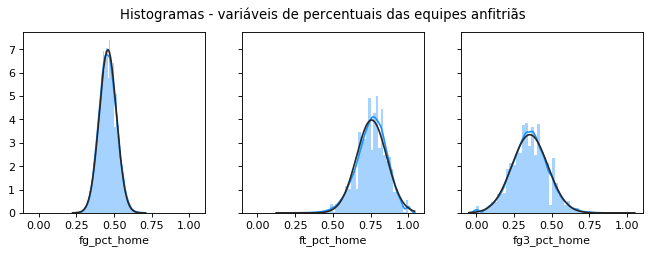

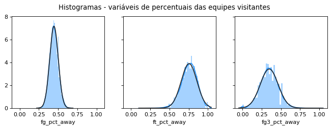

```python
# Histogramas das variáveis de percentual (Relatório: Figura 29)
histConstruct(modelGames, ['fg_pct_home', 'ft_pct_home', 'fg3_pct_home'], "variáveis de percentuais das equipes anfitriãs" )
histConstruct(modelGames, ['fg_pct_away', 'ft_pct_away', 'fg3_pct_away'], "variáveis de percentuais das equipes visitantes")
```

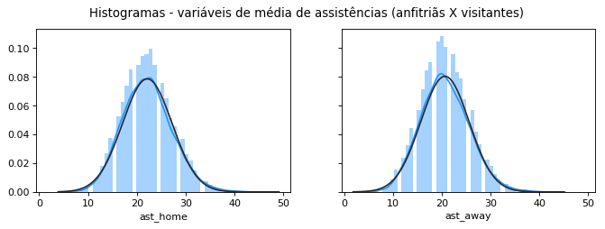

```python
# Histogramas das variáveis de assistências (Relatório: Figura 30)
histConstruct(modelGames, ['ast_home', 'ast_away'], "variáveis de média de assistências (anfitriãs X visitantes)" )
```

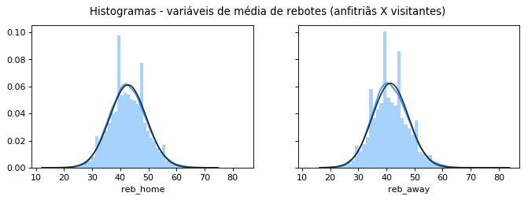

```python
# Histogramas das variáveis de rebotes (Relatório: Figura 31)
histConstruct(modelGames, ['reb_home', 'reb_away'], "variáveis de média de rebotes (anfitriãs X visitantes)")
```

Diante das visualizações confirmamos que temos praticamente uma Distribuição Normal em todas as variáveis preditoras. Além das respectivas barras de histograma com a distribuição, vemos uma linha uma linha azul nos gráficos representando a densidade das variáveis, sendo que esta praticamente segue o mesmo desenho da linha preta que representa o que seria a exata Distribuição Normal dela. A distribuição desta forma é muito importante e muito bem vinda em nossos atributos já que muitos algoritmos, em especial os lineares como por exemplo uma Regressão Logística, assumem que seus dados estão em uma Distribuição Normal para a respectiva modelagem.

De forma mais resumida verificamos se na Base de Previsões temos a mesma tendência de distribuição normal dos dados, assim ratificamos mais uma vez o êxito nas transformações e no propósito de simular uma nova temporada:

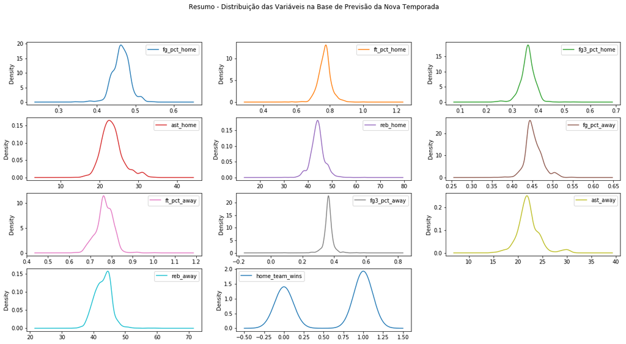

```python
# Construindo plot com múltiplos gráficos de densidade para as variáveis do dataset de previsões (Relatório: Figura 32)
modelNewSeason.plot(kind = 'density', figsize=(20, 10), subplots = True, layout = (4,3), sharex = False)
plt.suptitle("Resumo - Distribuição das Variáveis na Base de Previsão da Nova Temporada");
plt.show()
```

Com as linhas em “formato de sino” conseguimos ratificar que assim como acontece na Base Histórica, as variáveis na Base de Previsões seguem a tendência com distribuições que se aproximam de uma Distribuição Normal.

**Avaliação de “outliers”**

Verificamos agora, com a ajuda das visualizações chamadas de "box plots", se na Base Histórica existem dados extremos considerados "outliers". Dados extremos, em especial se ocorridos por erros cadastro ou ingestão, podem prejudicar a performance dos modelos ou mesmo demandar tratamentos mais específicos na base de dados. Identificá-los nos permite um tratamento prévio destes dados, se necessário.

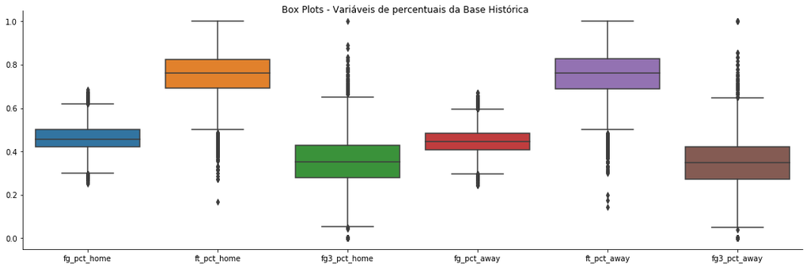

```python
# Gerando box plots das variáveis de percentuais da Base Histórica (Relatório: Figura 33)
pctVars = [x for x in modelGames if "pct" in x]
sns.catplot(data=modelGames[pctVars], kind="box", height=5, aspect=3);
plt.suptitle("Box Plots - Variáveis de percentuais da Base Histórica");
```

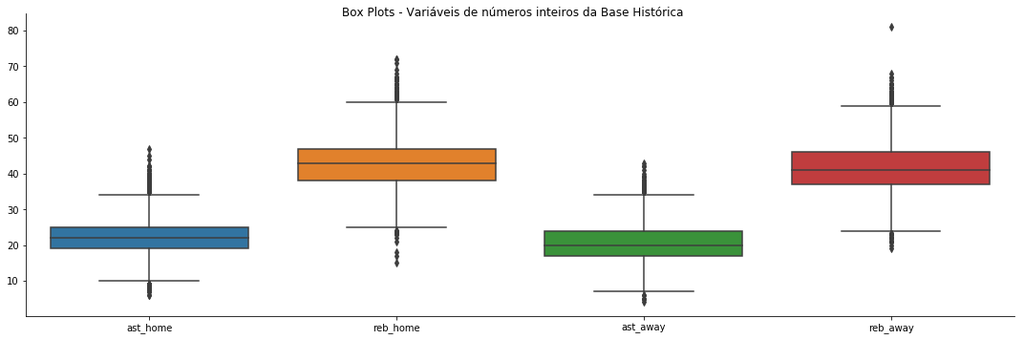

```python
# Gerando box plots das variáveis de números inteiros da Base Histórica (Relatório: Figura 34)
pctNums = [x for x in modelGames if "pct" not in x if "wins" not in x]
sns.catplot(data=modelGames[pctNums], kind="box", height=5, aspect=3);
plt.suptitle("Box Plots - Variáveis de números inteiros da Base Histórica");
```

É possível observar que em praticamente todos atributos temos pontos nos gráficos que poderiam ser considerados "outliers". Em todos há uma quantidade razoável assim ponderamos se de fato seriam anomalias ou, mesmo que extremos, são números reais que podem se repetem nos jogos que analisaremos. Uma boa comparação se dá quando observamos uma mesma métrica entre equipes anfitriãs e visitantes. Nota-se que na maioria das vezes os gráficos são praticamente iguais, inclusive ao que se refere a pontos extremos. No geral, esses pontos não parecem um erro de cadastro, ingestão, ou mesmo um "ponto fora da curva", já que ao visualizar o gráfico de sua variável correlata vemos a frequência facilmente se repetir.

Dado o acima, a princípio não excluiremos esses registros da base, mas geramos importantes insights para a preparação dos dados para a modelagem.

Vimos anteriormente que ter os atributos em uma mesma escala pode ser benéfico para os modelos e que poderíamos usar Normalização ou Padronização para esta tarefa. Com o insight coletado, sabemos que a Normalização não será adequada pois transforma os dados em um intervalo, digamos entre 0 e 1 ou 1 e 10, de forma que os números estejam na mesma escala. Como temos valores outliers em nosso conjunto, a Normalização certamente aumentará os dados "normais" para um intervalo muito pequeno, o que geralmente deve ser evitado.

Já ao usar a Padronização os “novos dados” não são limitados pois apenas fazemos o redimensionamento dos recursos.

**Balanceamento das Classes**

Sabemos que em nosso projeto o objetivo é prever os vencedores de jogos da NBA, que em nossos conjuntos de dados cada registro representa uma partida e que o atributo “home_team_wins” é quem identifica o vencedor. Sendo assim, este atributo é nossa variável resposta, quando “0” significa que a equipe visitante venceu e quando “1” que a equipe anfitriã foi a vencedora.

Quando trabalhamos um problema de classificação, que é exatamente o caso do nosso projeto, ter entre os registros da base de treinamento um balanceamento das classes (respostas possíveis) é muito importante, evitando que os modelos aprendam mais sobre uma classe do que outras.

Confirmamos então qual é a característica em nossa base.

```python
# Selecionando variável target e sua frequência:
gameResults = modelGames.groupby('home_team_wins')['home_team_wins'].count()
gameResults
```

```
home_team_wins
0     7775
1    11596
Name: home_team_wins, dtype: int64
```

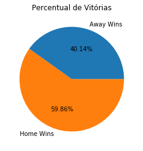

```python
# Gerando visualização com a proporção na variável target (Relatório: Figura 35)
values = [gameResults[0] , gameResults[1]]
labels = ['Away Wins' , 'Home Wins']
plt.pie(values , labels=labels, autopct=lambda p: '{}%'.format(round(p,2)))
plt.title('Percentual de Vitórias')
plt.show()
```

Há desbalanceamento entre o número de registros onde a equipe anfitriã foi a vencedora em comparação com o número de registros onde a equipe visitante venceu. A utilização de uma técnica de balanceamento se faz necessária na tentativa de obter desempenho equilibrado nos modelos de classificação.

**Processamento e tratamentos complementares dos dados**

Durante a análise exploratória pudemos conhecer mais de nossos conjuntos de dados, geramos insights e elencamos aspectos importantes que poderemos utilizar durante a modelagem. Vamos agora usar esse conhecimento adquirido para preparar diferentes versões dos conjuntos pra entrada (input) nos modelos que testaremos mais adiante.

Essas entradas que servirão para treinamento dos modelos são os atributos dos nossos conjuntos precisam ser transformados em vetores (“arrays”), separando as variáveis preditoras em um vetor diferente da variável resposta. Os tratamentos que serão feitos a seguir serão aplicados já sobre esses vetores.

```python
# Identificando índice da variável resposta no dataset modelGames (base histórica)
modelGames.columns.get_loc('home_team_wins')
```

```
10
```

```python
# Carregando os dados em um objeto array
histArray = modelGames.values

# Separando em componentes de input (variáveis preditoras = X) e output (variável resposta = Y)
X = histArray[:,0:10]
Y = histArray[:,10]
```

**Tratando o balanceamento das classes**

Como já citado anteriormente, ao haver mais registros com vitórias de anfitriões na base de treino, o modelo pode tender a responder melhor para esta classe, tendo um desempenho inferior para outra. Vamos revisar a distribuição das classes na variável resposta.

```
Quantidade por classe:
1.0    11596
0.0     7775
dtype: int64
```

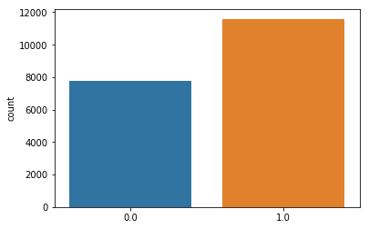

```python
# Contagem e visualização por classe da variável target na base de treino (Relatório: Figura 36)
print("Quantidade por classe:")
print(pd.Series(Y).value_counts())
sns.countplot(Y);
```

Para evitar desequilíbrio durante o processo de aprendizagem de modelos, vamos tratar este desbalanceamento utilizando uma técnica de “reamostragem”.

Se tivéssemos escassez de registros, poderíamos utilizar uma técnica de "Over Sampling", onde seriam criados registros das classes de menor número de forma sintética ou por meio de “clusterização”. Mas como temos um volume razoável de registros para treinamento, usaremos a técnica de "Under Sampling", onde o foco é reduzir o desbalanceamento do conjunto eliminando aleatoriamente entradas da classe com maior número de ocorrências.

```python
# Reamostragem dos dados de treino com Under Sampling
underSampler = RandomUnderSampler(random_state=2403)
X_balanced, Y_balanced = underSampler.fit_sample(X, Y)
```

Vejamos como ficou a distribuição das classes na versão da base de treinamento com dados balanceados.

```
Quantidade por classe:
1.0    7775
0.0    7775
dtype: int64
```

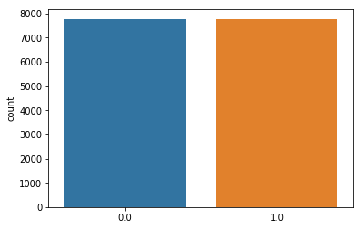

```python
# Contagem e visualização por classe da variável target na base de treino após reamostragem (Relatório: Figura 37)
print("Quantidade por classe:")
print(pd.Series(Y_balanced).value_counts())
sns.countplot(Y_balanced);
```

**Redimensionamento dos dados (Padronização)**

Utilizando a versão já balanceada, criaremos uma terceira versão de base para treinamento dos modelos, agora aplicando o redimensionamento dos dados.

A Padronização, amplamente utilizada em modelos SVMs (Support Vector Machine), regressão logística e redes neurais, transforma os dados de tal forma que eles tenham média zero e desvio padrão igual a um. Isso pode tornar o processo de treinamento melhor, porque a condição numérica dos problemas de otimização é melhorada.

```python
# Gerando o novo padrão para os dados (0 para a média, 1 para o desvio padrão)
standard = StandardScaler().fit(X_balanced)
X_standard = standard.transform(X_balanced)
```

```python
# Visualizando uma amostra dos dados originais X padronizados (Relatório: Figura 38)
print("Dados Originais: \n\n", X_balanced[0:3,:])
print("\nDados Padronizados: \n\n", X_standard[0:3,:])
```

```
Dados Originais:

 [[ 0.494  0.762  0.5   31.    35.     0.483  1.     0.25  24.    42.   ]
 [ 0.374  0.828  0.28  23.    45.     0.5    0.563  0.4   19.    44.   ]
 [ 0.462  0.769  0.2   20.    39.     0.482  0.806  0.429 22.    50.   ]]

Dados Padronizados:

 [[ 0.70792942  0.06614931  1.28608934  1.85321612 -1.14187473  0.55480977
   2.38648586 -0.88940626  0.61202588  0.03962298]
 [-1.4060604   0.7213603  -0.56485667  0.25002779  0.38815535  0.85737689
  -1.89623166  0.38616076 -0.38862627  0.35096066]
 [ 0.1441988   0.13564138 -1.23792795 -0.35116784 -0.5298627   0.53701171
   0.48523369  0.63277038  0.21176502  1.28497372]]
```

## Criação de Modelos de Machine Learning

Começaremos a construção dos modelos de aprendizado de máquina visando encontrar o algoritmo que melhor conseguirá prever os vencedores dos jogos da temporada 2017 da NBA.

Sabemos que o problema é de classificação e que como existem dados históricos devidamente classificados utilizaremos modelos de aprendizagem supervisionada, mas não há como saber antecipadamente qual algoritmo terá um melhor desempenho em prever corretamente os vencedores dos jogos. Sendo assim, testaremos diferentes modelos e ainda tentaremos otimizá-los com o intuito de atingir o nível de desempenho desejado quando definido o objetivo do projeto.

Iremos numerar e nomear cada modelo testado para uma fácil identificação dos mesmos no momento de apresentar os respectivos resultados.

Antes, para ratificar o citado na introdução deste trabalho (item 1.2), vamos fazer um breve teste de como seria o desempenho de um modelo simples, sem qualquer tratamento dos dados ou otimização de parâmetros, utilizando os dados dos próprios jogos, o que chamamos de “dados futuros”. Para isso, temporariamente dividiremos a Base Histórica em conjunto de treino (80%) para o devido treinamento do modelo e conjunto de teste (20%) para apurarmos a acurácia do mesmo.

```python
# Relatório: Figura 39

# Definindo o tamanho das amostra de teste
testSize = 0.20

# Definindo a semente para reprodução.
seed = 2403

# Criando os conjuntos de dados de treino e de teste
Xtrain, Xtest, Ytrain, Ytest = train_test_split(X, Y, test_size = testSize, random_state = seed)

# Criando do modelo
modeloTeste = LogisticRegression()

# Treinamento do modelo
modeloTeste.fit(Xtrain, Ytrain)
```

```
LogisticRegression(C=1.0, class_weight=None, dual=False, fit_intercept=True,
                   intercept_scaling=1, l1_ratio=None, max_iter=100,
                   multi_class='warn', n_jobs=None, penalty='l2',
                   random_state=None, solver='warn', tol=0.0001, verbose=0,
                   warm_start=False)
```

Modelo treinado, utilizamos o conjunto de teste para apurar seu desempenho.

```python
# Score do modelo teste com dados futuros (Relatório: Figura 40)
result1_0 = modeloTeste.score(Xtest, Ytest)
print("Acurácia Modelo de Teste: %.3f%%" % (result1_0 * 100.0))
```

```
Acurácia Modelo de Teste: 83.948%
```

Dentro do previsto, sem muito esforço alcançado acurácia de praticamente 84%, mas esse número não representa uma aplicação real do modelo. Este teste foi executado com o único objetivo de demonstrar como é importante o conhecimento do negócio em que estamos aplicando as técnicas de ciência de dados. Como já citado anteriormente, ao simular uma nova temporada, queremos prever os jogos que ainda não ocorreram e utilizar os próprios dados das partidas nas previsões seria como utilizar “dados futuros”.

Dado o acima, utilizaremos então como atributos de previsão (testes) as estatísticas acumuladas durante a temporada, apenas até os jogos que antecedem a partida a ser prevista, ou seja, os dados que obtivemos na confecção da nossa Base de Previsões.

```python
# Carregando os dados da Base de Testes em um objeto array
testArray = modelNewSeason.values

# Separando em componentes de input (variáveis preditoras= X_test) e output (variável resposta = Y_test)
X_test = testArray[:,0:10]
Y_test = testArray[:,10]

# Gerando o novo padrão para os dados de teste de modelos treinados com dados redimencionados
standardTest = StandardScaler().fit(X_test)
X_testStandard = standardTest.transform(X_test)
```

Como métricas de avaliação, utilizaremos não só a acurácia, mas também especificidade e sensibilidade (“Specificity” e “Sensitivity”) que estarão representando o percentual de acertos dos modelos para cada uma das classes individualmente, ou seja, classe 1 (vitória da equipe anfitriã) e classe 0 (vitória da equipe visitante) respectivamente. Para complementar, traremos ainda uma matriz de confusão (“Confusion Matrix”) acompanhada de um mapa de calor para ilustrar os resultados.

```python
# Função para gerar as métricas de avaliação dos modelos:
def class_score(test, pred):

    matrix = confusion_matrix(test, pred)
    print('Confusion Matrix:\n', matrix)

    accuracy = accuracy_score(test, pred)
    sensitivity = matrix[0,0] / (matrix[0,0] + matrix[0,1])
    specificity = matrix[1,1] / (matrix[1,0] + matrix[1,1])

    percent_matrix = [[sensitivity*100, (1-sensitivity)*100],[(1-specificity)*100, specificity*100]]

    print('\nPercentage Rating (by class):')
    labels = ['Class 0', 'Class 1']
    fig = plt.figure()
    ax = fig.add_subplot(111)
    cax = ax.matshow(percent_matrix, cmap=plt.cm.Reds)
    fig.colorbar(cax)
    ax.set_xticklabels([''] + labels)
    ax.set_yticklabels([''] + labels)
    plt.xlabel('Predicted')
    plt.ylabel('Expected')
    plt.show()

    print('\nAccuracy : %.2f%%' % (accuracy * 100))
    print('Sensitivity : %.2f%%' % (sensitivity * 100))
    print('Specificity : %.2f%%' % (specificity * 100))
```

### Regressão Logística

### Modelo 1.0 - Regressão Logística (Dados Originais)

```python
# Criando modelo
modelo1_0 = LogisticRegression(random_state=2403)

# Treinamento do modelo
modelo1_0.fit(X, Y)
```

```
LogisticRegression(C=1.0, class_weight=None, dual=False, fit_intercept=True,
                   intercept_scaling=1, l1_ratio=None, max_iter=100,
                   multi_class='warn', n_jobs=None, penalty='l2',
                   random_state=2403, solver='warn', tol=0.0001, verbose=0,
                   warm_start=False)
```

```
Regressão Logística
METRICAS MODELO 1.0 - Dados Originais:

Confusion Matrix:
 [[144 358]
 [117 574]]

Percentage Rating (by class):
```

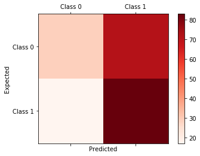

```
Accuracy : 60.18%
Sensitivity : 28.69%
Specificity : 83.07%
```

```python
# Realizando as previsões para o conjunto de teste
predict1_0 = modelo1_0.predict(X_test)

# Avaliando as previsões com a função de métricas (Relatório: Figura 44)
print('Regressão Logística')
print('METRICAS MODELO 1.0 - Dados Originais:\n')
class_score(Y_test, predict1_0)
```

### Modelo 1.1 - Regressão Logística (Dados Balanceados)

```python
# Criando modelo
modelo1_1 = LogisticRegression(random_state=2403)

# Treinamento do modelo
modelo1_1.fit(X_balanced, Y_balanced)
```

```
LogisticRegression(C=1.0, class_weight=None, dual=False, fit_intercept=True,
                   intercept_scaling=1, l1_ratio=None, max_iter=100,
                   multi_class='warn', n_jobs=None, penalty='l2',
                   random_state=2403, solver='warn', tol=0.0001, verbose=0,
                   warm_start=False)
```

```
Regressão Logística
METRICAS MODELO 1.1 - Dados Balanceados:

Confusion Matrix:
 [[231 271]
 [220 471]]

Percentage Rating (by class):
```

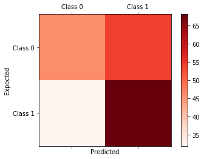

```
Accuracy : 58.84%
Sensitivity : 46.02%
Specificity : 68.16%
```

```python
# Realizando as previsões para o conjunto de teste
predict1_1 = modelo1_1.predict(X_test)

# Avaliando as previsões com a função de métricas (Relatório: Figura 44)
print('Regressão Logística')
print('METRICAS MODELO 1.1 - Dados Balanceados:\n')
class_score(Y_test, predict1_1)
```

### Modelo 1.2 - Regressão Logística (Dados Padronizados)

```python
# Criando modelo
modelo1_2 = LogisticRegression(random_state=2403)

# Treinamento do modelo
modelo1_2.fit(X_standard, Y_balanced)
```

```
LogisticRegression(C=1.0, class_weight=None, dual=False, fit_intercept=True,
                   intercept_scaling=1, l1_ratio=None, max_iter=100,
                   multi_class='warn', n_jobs=None, penalty='l2',
                   random_state=2403, solver='warn', tol=0.0001, verbose=0,
                   warm_start=False)
```

```
Regressão Logística
METRICAS MODELO 1.2 - Dados Padronizados:

Confusion Matrix:
 [[285 217]
 [275 416]]

Percentage Rating (by class):
```

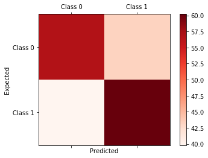

```
Accuracy : 58.76%
Sensitivity : 56.77%
Specificity : 60.20%
```

```python
# Realizando as previsões para o conjunto de teste
predict1_2 = modelo1_2.predict(X_testStandard)

# Avaliando as previsões com a função de métricas (Relatório: Figura 44)
print('Regressão Logística')
print('METRICAS MODELO 1.2 - Dados Padronizados:\n')
class_score(Y_test, predict1_2)
```

Os modelos com regressão logística tiveram precisão próxima ou superior a meta de 60%. Apesar da acurácia pouco mais baixa, o modelo que utilizou dados padronizados para treinamento claramente conseguiu obter o melhor equilíbrio de assertividade entre as classes.

Mais adiante realizaremos um procedimento de “tuning” no intuito de encontrar os melhores parâmetros para otimização dos modelos. Para regressão logística utilizaremos os dados padronizados como conjunto de treinamento.

### Random Forest

### Modelo 2.0 - Random Forest (Dados Originais)

```python
# Criando o modelo
modelo2_0 = RandomForestClassifier(random_state=2403, n_estimators=300)

# Treinando o modelo
modelo2_0.fit(X, Y)
```

```
RandomForestClassifier(bootstrap=True, class_weight=None, criterion='gini',
                       max_depth=None, max_features='auto', max_leaf_nodes=None,
                       min_impurity_decrease=0.0, min_impurity_split=None,
                       min_samples_leaf=1, min_samples_split=2,
                       min_weight_fraction_leaf=0.0, n_estimators=300,
                       n_jobs=None, oob_score=False, random_state=2403,
                       verbose=0, warm_start=False)
```

```
Random Forest
METRICAS MODELO 2.0 - Dados Originais:

Confusion Matrix:
 [[195 307]
 [178 513]]

Percentage Rating (by class):
```

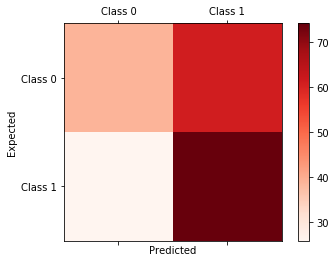

```
Accuracy : 59.35%
Sensitivity : 38.84%
Specificity : 74.24%
```

```python
# Realizando as previsões para o conjunto de teste
predict2_0 = modelo2_0.predict(X_test)

# Avaliando as previsões com a função de métricas (Relatório: Figura 48)
print('Random Forest')
print('METRICAS MODELO 2.0 - Dados Originais:\n')
class_score(Y_test, predict2_0)
```

### Modelo 2.1 - Random Forest (Dados Balanceados)

```python
# Criando o modelo
modelo2_1 = RandomForestClassifier(random_state=2403, n_estimators=300)

# Treinando o modelo
modelo2_1.fit(X_balanced, Y_balanced)
```

```
RandomForestClassifier(bootstrap=True, class_weight=None, criterion='gini',
                       max_depth=None, max_features='auto', max_leaf_nodes=None,
                       min_impurity_decrease=0.0, min_impurity_split=None,
                       min_samples_leaf=1, min_samples_split=2,
                       min_weight_fraction_leaf=0.0, n_estimators=300,
                       n_jobs=None, oob_score=False, random_state=2403,
                       verbose=0, warm_start=False)
```

```
Random Forest
METRICAS MODELO 2.1 - Dados Balanceados:

Confusion Matrix:
 [[273 229]
 [275 416]]

Percentage Rating (by class):
```

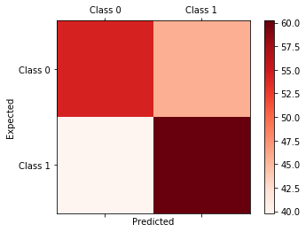

```
Accuracy : 57.75%
Sensitivity : 54.38%
Specificity : 60.20%
```

```python
# Realizando as previsões para o conjunto de teste
predict2_1 = modelo2_1.predict(X_test)

# Avaliando as previsões com a função de métricas (Relatório: Figura 48)
print('Random Forest')
print('METRICAS MODELO 2.1 - Dados Balanceados:\n')
class_score(Y_test, predict2_1)
```

### Modelo 2.2 - Random Forest (Dados Padronizados)

```python
# Criando o modelo
modelo2_2 = RandomForestClassifier(random_state=2403, n_estimators=300)

# Treinando o modelo
modelo2_2.fit(X_standard, Y_balanced)
```

```
RandomForestClassifier(bootstrap=True, class_weight=None, criterion='gini',
                       max_depth=None, max_features='auto', max_leaf_nodes=None,
                       min_impurity_decrease=0.0, min_impurity_split=None,
                       min_samples_leaf=1, min_samples_split=2,
                       min_weight_fraction_leaf=0.0, n_estimators=300,
                       n_jobs=None, oob_score=False, random_state=2403,
                       verbose=0, warm_start=False)
```

```
Random Forest
METRICAS MODELO 2.2 - Dados Padronizados:

Confusion Matrix:
 [[281 221]
 [276 415]]

Percentage Rating (by class):
```

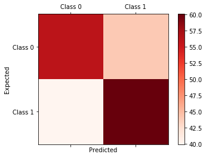

```
Accuracy : 58.34%
Sensitivity : 55.98%
Specificity : 60.06%
```

```python
# Realizando as previsões para o conjunto de teste
predict2_2 = modelo2_2.predict(X_testStandard)

# Avaliando as previsões com a função de métricas (Relatório: Figura 48)
print('Random Forest')
print('METRICAS MODELO 2.2 - Dados Padronizados:\n')
class_score(Y_test, predict2_2)
```

### Support Vector Machines

### Modelo 3.0 - SVM (Dados Originais)

```python
# Criando o modelo
modelo3_0 = SVC(random_state=2403)

# Treinando o modelo
modelo3_0.fit(X, Y)
```

```
SVC(C=1.0, cache_size=200, class_weight=None, coef0=0.0,
    decision_function_shape='ovr', degree=3, gamma='auto_deprecated',
    kernel='rbf', max_iter=-1, probability=False, random_state=2403,
    shrinking=True, tol=0.001, verbose=False)
```

```
SVM
METRICAS MODELO 3.0 - Dados Originais:

Confusion Matrix:
 [[169 333]
 [171 520]]

Percentage Rating (by class):
```

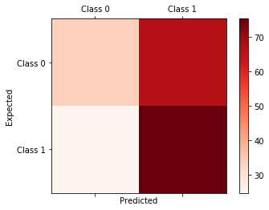

```
Accuracy : 57.75%
Sensitivity : 33.67%
Specificity : 75.25%
```

```python
# Realizando as previsões para o conjunto de teste
predict3_0 = modelo3_0.predict(X_test)

# Avaliando as previsões com a função de métricas (Relatório: Figura 52)
print('SVM')
print('METRICAS MODELO 3.0 - Dados Originais:\n')
class_score(Y_test, predict3_0)
```

### Modelo 3.1 - SVM (Dados Balanceados)

```python
# Criando o modelo
modelo3_1 = SVC(random_state=2403)

# Treinando o modelo
modelo3_1.fit(X_balanced, Y_balanced)
```

```
SVC(C=1.0, cache_size=200, class_weight=None, coef0=0.0,
    decision_function_shape='ovr', degree=3, gamma='auto_deprecated',
    kernel='rbf', max_iter=-1, probability=False, random_state=2403,
    shrinking=True, tol=0.001, verbose=False)
```

```
SVM
METRICAS MODELO 3.1 - Dados Balanceados:

Confusion Matrix:
 [[302 200]
 [325 366]]

Percentage Rating (by class):
```

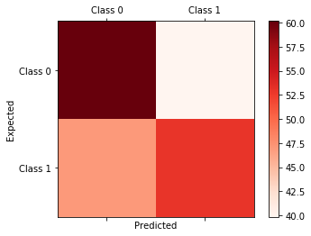

```
Accuracy : 55.99%
Sensitivity : 60.16%
Specificity : 52.97%
```

```python
# Realizando as previsões para o conjunto de teste
predict3_1 = modelo3_1.predict(X_test)

# Avaliando as previsões com a função de métricas (Relatório: Figura 52)
print('SVM')
print('METRICAS MODELO 3.1 - Dados Balanceados:\n')
class_score(Y_test, predict3_1)
```

### Modelo 3.2 - SVM (Dados Padronizados)

```python
# Criando o modelo
modelo3_2 = SVC(random_state=2403)

# Treinando o modelo
modelo3_2.fit(X_standard, Y_balanced)
```

```
SVC(C=1.0, cache_size=200, class_weight=None, coef0=0.0,
    decision_function_shape='ovr', degree=3, gamma='auto_deprecated',
    kernel='rbf', max_iter=-1, probability=False, random_state=2403,
    shrinking=True, tol=0.001, verbose=False)
```

```
SVM
METRICAS MODELO 3.2 - Dados Padronizados:

Confusion Matrix:
 [[285 217]
 [286 405]]

Percentage Rating (by class):
```

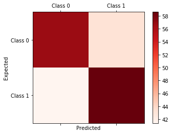

```
Accuracy : 57.84%
Sensitivity : 56.77%
Specificity : 58.61%
```

```python
# Realizando as previsões para o conjunto de teste
predict3_2 = modelo3_2.predict(X_testStandard)

# Avaliando as previsões com a função de métricas (Relatório: Figura 52)
print('SVM')
print('METRICAS MODELO 3.2 - Dados Padronizados:\n')
class_score(Y_test, predict3_2)
```

Até aqui o algoritmo de Support Vector Machines foi o que teve o desempenho mais baixo, ficando abaixo de 58% em todas versões do conjunto. Assim como ocorreu nos anteriores, o modelo treinado com dados padronizados se saiu melhor que os demais e passará pelo processo de otimização.

### XGBoost

### Modelo 4.0 - XGBoost (Dados Originais)

```python
# Criando o modelo
modelo4_0 = XGBClassifier(seed=2403)

# Treinando o modelo
modelo4_0.fit(X, Y)
```

```
XGBClassifier(base_score=0.5, booster='gbtree', colsample_bylevel=1,
              colsample_bynode=1, colsample_bytree=1, gamma=0,
              learning_rate=0.1, max_delta_step=0, max_depth=3,
              min_child_weight=1, missing=None, n_estimators=100, n_jobs=1,
              nthread=None, objective='binary:logistic', random_state=0,
              reg_alpha=0, reg_lambda=1, scale_pos_weight=1, seed=2403,
              silent=None, subsample=1, verbosity=1)
```

```
XGBoost
METRICAS MODELO 4.0 - Dados Originais:

Confusion Matrix:
 [[200 302]
 [172 519]]

Percentage Rating (by class):
```

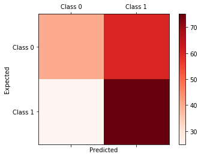

```
Accuracy : 60.27%
Sensitivity : 39.84%
Specificity : 75.11%
```

```python
# Realizando as previsões para o conjunto de teste
predict4_0 = modelo4_0.predict(X_test)

# Avaliando as previsões com a função de métricas (Relatório: Figura 56)
print('XGBoost')
print('METRICAS MODELO 4.0 - Dados Originais:\n')
class_score(Y_test, predict4_0)
```

### Modelo 4.1 - XGBoost (Dados Balanceados)

```python
# Criando o modelo
modelo4_1 = XGBClassifier(seed=2403)

# Treinando o modelo
modelo4_1.fit(X_balanced, Y_balanced)
```

```
XGBClassifier(base_score=0.5, booster='gbtree', colsample_bylevel=1,
              colsample_bynode=1, colsample_bytree=1, gamma=0,
              learning_rate=0.1, max_delta_step=0, max_depth=3,
              min_child_weight=1, missing=None, n_estimators=100, n_jobs=1,
              nthread=None, objective='binary:logistic', random_state=0,
              reg_alpha=0, reg_lambda=1, scale_pos_weight=1, seed=2403,
              silent=None, subsample=1, verbosity=1)
```

```
XGBoost
METRICAS MODELO 4.1 - Dados Balanceados:

Confusion Matrix:
 [[272 230]
 [254 437]]

Percentage Rating (by class):
```

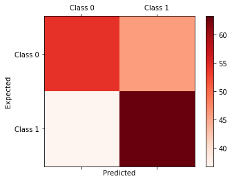

```
Accuracy : 59.43%
Sensitivity : 54.18%
Specificity : 63.24%
```

```python
# Realizando as previsões para o conjunto de teste
predict4_1 = modelo4_1.predict(X_test)

# Avaliando as previsões com a função de métricas (Relatório: Figura 56)
print('XGBoost')
print('METRICAS MODELO 4.1 - Dados Balanceados:\n')
class_score(Y_test, predict4_1)
```

### Modelo 4.2 - XGBoost (Dados Padronizados)

```python
# Criando o modelo
modelo4_2 = XGBClassifier(seed=2403)

# Treinando o modelo
modelo4_2.fit(X_standard, Y_balanced)
```

```
XGBClassifier(base_score=0.5, booster='gbtree', colsample_bylevel=1,
              colsample_bynode=1, colsample_bytree=1, gamma=0,
              learning_rate=0.1, max_delta_step=0, max_depth=3,
              min_child_weight=1, missing=None, n_estimators=100, n_jobs=1,
              nthread=None, objective='binary:logistic', random_state=0,
              reg_alpha=0, reg_lambda=1, scale_pos_weight=1, seed=2403,
              silent=None, subsample=1, verbosity=1)
```

```
XGBoost
METRICAS MODELO 4.2 - Dados Padronizados:

Confusion Matrix:
 [[286 216]
 [298 393]]

Percentage Rating (by class):
```

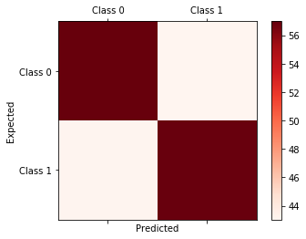

```
Accuracy : 56.92%
Sensitivity : 56.97%
Specificity : 56.87%
```

```python
# Realizando as previsões para o conjunto de teste
predict4_2 = modelo4_2.predict(X_testStandard)

# Avaliando as previsões com a função de métricas (Relatório: Figura 56)
print('XGBoost')
print('METRICAS MODELO 4.2 - Dados Padronizados:\n')
class_score(Y_test, predict4_2)
```

Com o modelo de Extreme Gradient Boosting obtivemos a maior acurácia até o momento com 60,27%, porém nesta versão com os dados originais temos um desequilíbrio em relação a assertividade entre as classes. Já com os dados padronizados temos um ótimo equilíbrio, apesar da acurácia mais baixa entre todos. Assim como nos demais, utilizaremos a versão padronizada na otimização.

## Otimização dos modelos através de ajustes de hiperparâmetros

Diferente dos parâmetros que são estimados a partir dos próprios dados, os hiperparâmetros são características externas que precisam ser definidas antes do treinamento dos modelos. Também chamado de “tuning” ou “ajuste fino”, os ajustes dos hyperparâmetros são importantes pois o desempenho dos modelos é diretamente afetado por esse sensível processo.

Até aqui, todos os modelos criados em nosso projeto utilizaram os hiperparâmetros padrão para os mesmos. Vamos agora utilizar os modelos selecionados para tentar otimizar seu desempenho a partir de ajustes finos em suas configurações.

Para ajudar na determinação dos hiperparâmetros, vamos utilizar o método “Grid Search Parameter Tuning” que nos auxilia na definição dos valores através de testes com validação cruzada de várias combinações a partir de um grid.

O objetivo é alcançar o maior desempenho possível dentre os modelos que estamos testando.

### Grid Search – Modelo de Regressão Logística

```python
# Criando modelo
modeloRL = LogisticRegression(random_state=2403)

# Criando o grid de valores
valores_gridRL = {'penalty': ['l1','l2'],
                'C': [0.1, 0.5, 1, 2, 3, 4, 5, 6, 7, 8, 9, 10, 15, 20],
                'max_iter': [100, 150, 200, 250, 300, 350, 400],
                'tol': [0.0001, 0.0002, 0.0003, 0.0004, 0.0005, 0.001, 0.005]}

# Configurando grid
gridRL = GridSearchCV(estimator = modeloRL,
                    param_grid = valores_gridRL,
                    cv = 10,
                    n_jobs = 10,
                    scoring = 'accuracy',
                    verbose = True)

# Treinamento (Buscando melhor configuração de hiperparametros)
gridRL.fit(X_standard, Y_balanced)
```

```
Fitting 10 folds for each of 1372 candidates, totalling 13720 fits
```

[output not shown]

```
GridSearchCV(cv=10, error_score='raise-deprecating',
             estimator=LogisticRegression(C=1.0, class_weight=None, dual=False,
                                          fit_intercept=True,
                                          intercept_scaling=1, l1_ratio=None,
                                          max_iter=100, multi_class='warn',
                                          n_jobs=None, penalty='l2',
                                          random_state=2403, solver='warn',
                                          tol=0.0001, verbose=0,
                                          warm_start=False),
             iid='warn', n_jobs=10,
             param_grid={'C': [0.1, 0.5, 1, 2, 3, 4, 5, 6, 7, 8, 9, 10, 15, 20],
                         'max_iter': [100, 150, 200, 250, 300, 350, 400],
                         'penalty': ['l1', 'l2'],
                         'tol': [0.0001, 0.0002, 0.0003, 0.0004, 0.0005, 0.001,
                                 0.005]},
             pre_dispatch='2*n_jobs', refit=True, return_train_score=False,
             scoring='accuracy', verbose=True)
```

```python
# Confirmando o melhor modelo
print("Melhores Hiperparâmetros para o Modelo:\n\n", gridRL.best_estimator_)
print("\nAcurácia obtida: %.3f" % (gridRL.best_score_ * 100))
```

```
Melhores Hiperparâmetros para o Modelo:

 LogisticRegression(C=0.1, class_weight=None, dual=False, fit_intercept=True,
                   intercept_scaling=1, l1_ratio=None, max_iter=100,
                   multi_class='warn', n_jobs=None, penalty='l1',
                   random_state=2403, solver='warn', tol=0.0001, verbose=0,
                   warm_start=False)

Acurácia obtida: 83.524
```

### Grid Search – Modelo Random Forest

```python
# Criando modelo
modeloRF = RandomForestClassifier(random_state=2403)

# Criando o grid de valores
valores_gridRF = {'max_features': ['auto', 'sqrt'],
                  'max_depth': [None, 5, 10, 20, 50],
                  'min_samples_split': [2, 5, 10],
                  'min_samples_leaf': [1, 2, 4],
                  'bootstrap': [True, False],
                  'n_estimators': [100, 200, 300]}

# Configurando grid
gridRF = GridSearchCV(estimator = modeloRF,
                    param_grid = valores_gridRF,
                    cv = 10,
                    n_jobs = 10,
                    scoring = 'accuracy',
                    verbose = True)

# Treinamento (Buscando melhor configuração de hiperparametros)
gridRF.fit(X_standard, Y_balanced)
```

```
Fitting 10 folds for each of 540 candidates, totalling 5400 fits
```

[output not shown]

```
GridSearchCV(cv=10, error_score='raise-deprecating',
             estimator=RandomForestClassifier(bootstrap=True, class_weight=None,
                                              criterion='gini', max_depth=None,
                                              max_features='auto',
                                              max_leaf_nodes=None,
                                              min_impurity_decrease=0.0,
                                              min_impurity_split=None,
                                              min_samples_leaf=1,
                                              min_samples_split=2,
                                              min_weight_fraction_leaf=0.0,
                                              n_estimators='warn', n_jobs=None,
                                              oob_score=False,
                                              random_state=2403, verbose=0,
                                              warm_start=False),
             iid='warn', n_jobs=10,
             param_grid={'bootstrap': [True, False],
                         'max_depth': [None, 5, 10, 20, 50],
                         'max_features': ['auto', 'sqrt'],
                         'min_samples_leaf': [1, 2, 4],
                         'min_samples_split': [2, 5, 10],
                         'n_estimators': [100, 200, 300]},
             pre_dispatch='2*n_jobs', refit=True, return_train_score=False,
             scoring='accuracy', verbose=True)
```

```python
# Confirmando o melhor modelo
print("Melhores Hiperparâmetros para o Modelo:\n\n", gridRF.best_estimator_)
print("\nAcurácia obtida: %.3f" % (gridRF.best_score_ * 100))
```

```
Melhores Hiperparâmetros para o Modelo:

 RandomForestClassifier(bootstrap=True, class_weight=None, criterion='gini',
                       max_depth=20, max_features='auto', max_leaf_nodes=None,
                       min_impurity_decrease=0.0, min_impurity_split=None,
                       min_samples_leaf=2, min_samples_split=5,
                       min_weight_fraction_leaf=0.0, n_estimators=100,
                       n_jobs=None, oob_score=False, random_state=2403,
                       verbose=0, warm_start=False)

Acurácia obtida: 83.023
```

### Grid Search – Modelo SVM

```python
# Criando modelo
modeloSVM = SVC(random_state=2403)

# Criando o grid de valores
valores_gridSVM = [{'kernel': ['rbf'],
                    'gamma': [1e-3, 1e-4],
                    'C': [0.1, 1, 10, 100, 1000]},
                   {'kernel': ['linear'],
                    'C': [0.1, 1, 10, 100, 1000]}]

# Configurando grid
gridSVM = GridSearchCV(estimator = modeloSVM,
                    param_grid = valores_gridSVM,
                    cv = 10,
                    n_jobs = 10,
                    scoring = 'accuracy',
                    verbose = True)

# Treinamento (Buscando melhor configuração de hiperparametros)
gridSVM.fit(X_standard, Y_balanced)
```

```
Fitting 10 folds for each of 15 candidates, totalling 150 fits
```

```
[Parallel(n_jobs=10)]: Using backend LokyBackend with 10 concurrent workers.
[Parallel(n_jobs=10)]: Done  30 tasks      | elapsed:  1.3min
[Parallel(n_jobs=10)]: Done 150 out of 150 | elapsed: 59.4min finished
```

```
GridSearchCV(cv=10, error_score='raise-deprecating',
             estimator=SVC(C=1.0, cache_size=200, class_weight=None, coef0=0.0,
                           decision_function_shape='ovr', degree=3,
                           gamma='auto_deprecated', kernel='rbf', max_iter=-1,
                           probability=False, random_state=2403, shrinking=True,
                           tol=0.001, verbose=False),
             iid='warn', n_jobs=10,
             param_grid=[{'C': [0.1, 1, 10, 100, 1000],
                          'gamma': [0.001, 0.0001], 'kernel': ['rbf']},
                         {'C': [0.1, 1, 10, 100, 1000], 'kernel': ['linear']}],
             pre_dispatch='2*n_jobs', refit=True, return_train_score=False,
             scoring='accuracy', verbose=True)
```

```python
# Confirmando o melhor modelo
print("Melhores Hiperparâmetros para o Modelo:\n\n", gridSVM.best_estimator_)
print("\nAcurácia obtida: %.3f" % (gridSVM.best_score_ * 100))
```

```
Melhores Hiperparâmetros para o Modelo:

 SVC(C=100, cache_size=200, class_weight=None, coef0=0.0,
    decision_function_shape='ovr', degree=3, gamma=0.001, kernel='rbf',
    max_iter=-1, probability=False, random_state=2403, shrinking=True,
    tol=0.001, verbose=False)

Acurácia obtida: 83.723
```

### Grid Search – Modelo XGBoost

```python
# Criando modelo
modeloXGB = XGBClassifier(objective= 'binary:logistic', nthread=4, seed=2403)

# Criando o grid de valores
valores_gridXGB = {'max_depth': [3, 4, 5, 6, 8, 10],
                   'n_estimators': [100, 200, 300],
                   'learning_rate': [0.01, 0.05, 0.1, 0.5],
                   'min_child_weight' : [1, 3, 5, 7],
                   'gamma': [0.0, 0.1, 0.2 , 0.3],
                   'colsample_bytree' : [ 0.3, 0.4, 0.5]}

# Configurando grid
gridXGB = GridSearchCV(estimator = modeloXGB,
                    param_grid = valores_gridXGB,
                    cv = 10,
                    n_jobs = 10,
                    scoring = 'accuracy',
                    verbose = True)

# Treinamento (Buscando melhor configuração de hiperparametros)
gridXGB.fit(X_standard, Y_balanced)
```

```
Fitting 10 folds for each of 3456 candidates, totalling 34560 fits
```

[output not shown]

```
GridSearchCV(cv=10, error_score='raise-deprecating',
             estimator=XGBClassifier(base_score=0.5, booster='gbtree',
                                     colsample_bylevel=1, colsample_bynode=1,
                                     colsample_bytree=1, gamma=0,
                                     learning_rate=0.1, max_delta_step=0,
                                     max_depth=3, min_child_weight=1,
                                     missing=None, n_estimators=100, n_jobs=1,
                                     nthread=4, objective='binary:logistic',
                                     random_state=0, reg_alpha=0, reg_lam...
                                     scale_pos_weight=1, seed=2403, silent=None,
                                     subsample=1, verbosity=1),
             iid='warn', n_jobs=10,
             param_grid={'colsample_bytree': [0.3, 0.4, 0.5],
                         'gamma': [0.0, 0.1, 0.2, 0.3],
                         'learning_rate': [0.01, 0.05, 0.1, 0.5],
                         'max_depth': [3, 4, 5, 6, 8, 10],
                         'min_child_weight': [1, 3, 5, 7],
                         'n_estimators': [100, 200, 300]},
             pre_dispatch='2*n_jobs', refit=True, return_train_score=False,
             scoring='accuracy', verbose=True)
```

```python
# Confirmando o melhor modelo
print("Melhores Hiperparâmetros para o Modelo:\n\n", gridXGB.best_estimator_)
print("\nAcurácia obtida: %.3f" % (gridXGB.best_score_ * 100))
```

```
Melhores Hiperparâmetros para o Modelo:

 XGBClassifier(base_score=0.5, booster='gbtree', colsample_bylevel=1,
              colsample_bynode=1, colsample_bytree=0.3, gamma=0.1,
              learning_rate=0.05, max_delta_step=0, max_depth=3,
              min_child_weight=5, missing=None, n_estimators=300, n_jobs=1,
              nthread=4, objective='binary:logistic', random_state=0,
              reg_alpha=0, reg_lambda=1, scale_pos_weight=1, seed=2403,
              silent=None, subsample=1, verbosity=1)

Acurácia obtida: 83.775
```

Após aproximadamente 12 horas de processamento contínuo, selecionamos quatro combinações de modelos, uma para cada algoritmo, em busca de obter uma elevação na performance até aqui obtida durante o período de modelagem. No entanto as acurácias apuradas nas combinações com melhor performance não indicam que teremos grandes diferenças das versões originais, já que estas são próximas ao resultado daquele primeiro teste feito com os dados das partidas já decorridas em um modelo simples de regressão logística.

Vale ressaltar que o grid de parâmetros estipulados para testar combinações é bastante flexível e poderíamos aumentar substantivamente o número de estimadores testados para fazer a melhor escolha. Por outro lado, como já se pode notar nos processamentos acima, o custo computacional para realização é alto e por isso submeter grids maiores para testes é uma escolha delicada, um “trade-off” que precisa considerar o tempo e o hardware disponíveis para execução da tarefa.

### Treinamento e Avaliação dos modelos com as combinações selecionadas

```
Regressão Logística
METRICAS MODELO 1.3 - Otimizado:

Confusion Matrix:
 [[285 217]
 [274 417]]

Percentage Rating (by class):
```

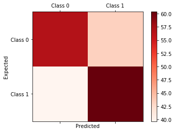

```
Accuracy : 58.84%
Sensitivity : 56.77%
Specificity : 60.35%
```

```python
# Modelo 1.3 - Regressão Logistica após Grid Search
modelo1_3 = LogisticRegression(C=0.1, class_weight=None, dual=False, fit_intercept=True,
                   intercept_scaling=1, l1_ratio=None, max_iter=100,
                   multi_class='warn', n_jobs=None, penalty='l1',
                   random_state=2403, solver='warn', tol=0.0001, verbose=0,
                   warm_start=False)

# Treinando modelo
modelo1_3.fit(X_standard, Y_balanced)

# Realizando as previsões para o conjunto de teste
predict1_3 = modelo1_3.predict(X_testStandard)

# Avaliando as previsões com a função de métricas (Relatório: Figura 61)
print('Regressão Logística')
print('METRICAS MODELO 1.3 - Otimizado:\n')
class_score(Y_test, predict1_3)
```

```
Random Forest
METRICAS MODELO 2.3 - Otimizado:

Confusion Matrix:
 [[283 219]
 [282 409]]

Percentage Rating (by class):
```

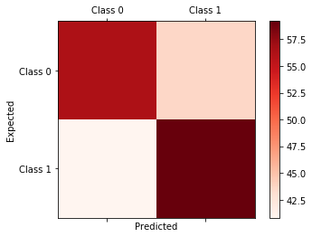

```
Accuracy : 58.01%
Sensitivity : 56.37%
Specificity : 59.19%
```

```python
# Modelo 2.3 - Random Forest após Grid Search
modelo2_3 = RandomForestClassifier(bootstrap=True, class_weight=None, criterion='gini',
                       max_depth=20, max_features='auto', max_leaf_nodes=None,
                       min_impurity_decrease=0.0, min_impurity_split=None,
                       min_samples_leaf=2, min_samples_split=5,
                       min_weight_fraction_leaf=0.0, n_estimators=100,
                       n_jobs=None, oob_score=False, random_state=2403,
                       verbose=0, warm_start=False)

# Treinando modelo
modelo2_3.fit(X_standard, Y_balanced)

# Realizando as previsões para o conjunto de teste
predict2_3 = modelo2_3.predict(X_testStandard)

# Avaliando as previsões com a função de métricas (Relatório: Figura 61)
print('Random Forest')
print('METRICAS MODELO 2.3 - Otimizado:\n')
class_score(Y_test, predict2_3)
```

```
SVM
METRICAS MODELO 3.3 - Otimizado:

Confusion Matrix:
 [[291 211]
 [282 409]]

Percentage Rating (by class):
```

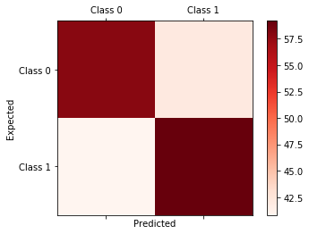

```
Accuracy : 58.68%
Sensitivity : 57.97%
Specificity : 59.19%
```

```python
# Modelo 3.3 - SVM após Grid Search
modelo3_3 = SVC(C=100, cache_size=200, class_weight=None, coef0=0.0,
                decision_function_shape='ovr', degree=3, gamma=0.001, kernel='rbf',
                max_iter=-1, probability=False, random_state=2403, shrinking=True,
                tol=0.001, verbose=False)

# Treinando modelo
modelo3_3.fit(X_standard, Y_balanced)

# Realizando as previsões para o conjunto de teste
predict3_3 = modelo3_3.predict(X_testStandard)

# Avaliando as previsões com a função de métricas (Relatório: Figura 61)
print('SVM')
print('METRICAS MODELO 3.3 - Otimizado:\n')
class_score(Y_test, predict3_3)
```

```
XGBoost
METRICAS MODELO 4.3 - Otimizado:

Confusion Matrix:
 [[292 210]
 [293 398]]

Percentage Rating (by class):
```

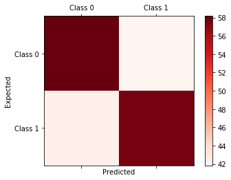

```
Accuracy : 57.84%
Sensitivity : 58.17%
Specificity : 57.60%
```

```python
# Modelo 4.3 - XGBoost após Grid Search
modelo4_3 = XGBClassifier(base_score=0.5, booster='gbtree', colsample_bylevel=1,
              colsample_bynode=1, colsample_bytree=0.3, gamma=0.1,
              learning_rate=0.05, max_delta_step=0, max_depth=3,
              min_child_weight=5, missing=None, n_estimators=300, n_jobs=1,
              nthread=4, objective='binary:logistic', random_state=0,
              reg_alpha=0, reg_lambda=1, scale_pos_weight=1, seed=2403,
              silent=None, subsample=1, verbosity=1)

# Treinando modelo
modelo4_3.fit(X_standard, Y_balanced)

# Realizando as previsões para o conjunto de teste
predict4_3 = modelo4_3.predict(X_testStandard)

# Avaliando as previsões com a função de métricas (Relatório: Figura 61)
print('XGBoost')
print('METRICAS MODELO 4.3 - Otimizado:\n')
class_score(Y_test, predict4_3)
```

É intrigante verificar como quatro algoritmos diferentes, submetidos a diversas combinações de parâmetros diferentes, produzem resultados tão próximos. Por outro lado, traz confiança aos resultados já que não há grandes oscilações entre as diferentes versões.

Diante de tamanha semelhança, para uma aplicação em produção, minha escolha particular seria pelo Modelo 1.3 de Regressão Logística. Isso porque trata-se de um algoritmo mais simples, o que menos requer recursos computacionais para execução, possibilita um nível de “explicabilidade” para seu resultado e ainda nos testes foi o que teve melhor precisão aliado ao equilíbrio de assertividade entre as classes previstas corretamente.

## Considerações

Conforme esperado, não conseguimos obter índices de acurácia elevados, mesmo testando diversos modelos e parâmetros. Comprovamos que prever um resultado apenas com estimativas do que serão os dados reais de uma partida futura é extremamente complexo. Porém, mesmo com tamanha complexidade, conseguimos alcançar índices de precisão próximos de 60%, demonstrando que é sim minimamente possível, baseado em dados, apontar um favorito para vitória.

Interessante também comprovar como a preparação dos dados tem importância fundamental no resultado das previsões, facilmente visualizado no melhor equilíbrio da assertividade entre as classes possíveis depois da aplicação de técnicas de balanceamento e padronização dos conjuntos de treinamento.

Apuramos ainda que até a otimização dos hiperparâmetros dos modelos é dificultada pela característica do problema proposto, visto que a validação do estimador vencedor se dá por uma métrica sobre os dados das partidas já ocorridas. Testando diferentes combinações destes parâmetros em somadas mais de 12 árduas horas de processamento, conseguimos em alguns algoritmos melhorar somente superficialmente a acurácia final.

Exposto o acima, é importante registrar que os resultados apresentados não são definitivos, longe disso, sempre há possibilidade de melhora seja pela incorporação de novos atributos, diferentes tratamentos e transformações, experimentação de outros algoritmos ou mesmo teste de uma maior quantidade de combinações de parâmetros dos modelos. Cabendo ressaltar também que para parte dessas indicações, um poder computacional mais elevado seria requerido.

## Conclusão

Respondendo à pergunta efetuada no início do projeto quando propusemos o problema a ser resolvido: sim, podemos indicar o favorito a vencer um jogo da NBA, além da aleatoriedade ou do mero palpite, com base em números e estatísticas coletadas durante uma temporada específica.

Ainda que o índice de precisão não seja dos mais elevados, o que é perfeitamente normal dada a competitividade da liga como exaustivamente já discutimos no decorrer do processo, é o suficiente para apontar o favoritismo de uma das equipes tendo uma assertividade em cerca de 59% das previsões.

Um modelo como o selecionado, ou mesmo um “blend” dos modelos testados, poderiam ser monetizados ao alimentar um site de sugestão de apostas, de indicações para “Fantasy Games” ou até mesmo, com algumas melhorias e aprimoramentos, ajudar comissões técnicas das equipes na preparação que antecede os jogos.

**Trabalho de Conclusão de Curso**  
**PONTIFÍCIA UNIVERSIDADE CATÓLICA DE MINAS GERAIS**  
**Curso:** *Pós-graduação Lato Sensu em Ciência de Dados e Big Data*  
**Aluno:** *Geraldo Rodrigues Novais Junior*